# Two-sample Testing Application

I-Lun Tu

# Introduction

- Discerning the differences between two samples is a classic and important issue of statistical testing:

In financial settings, this statistical method can be applied to understand whether two stocks/ portfolios behave similarly regarding returns and risks. However, most of the time, financial data are fat-tailed and highly auto-correlated as well as highly correlated with other stocks to be tested against, making the normal IID assumption hard to satisfy. To address these pitfalls, in this report, randomized paired methods and differencing are utilized to overcome the normal assumption and factor in the correlation. Overall, these methods will be more flexible and robust.

In business settings, this statistical procedure is often applied to understand whether two groups of potential customers behave similarly, such as A/B testings. With this information, marketing managers can decide why and how to tailor different marketing campaigns to better cater to potential customers. However, it is often not obvious which kinds of tests one should use when confronted with various different constrains posed by the data at hand, such as non-normal distributions, high dimensions, small sample size, etc. Therefore, in this report, various tests are proposed and tuned and guidelines are provided when facing different constraint.

- Nearest Neighbor Test (NNT)
- Energy-based Test (EBT)
- Hotelling’s T-squared Test (HTT)
- Graphed-based Two-sample Test (GST)

The efficacy of a statistical test depends on many factors. Listed below are the factors considered in this report. After understanding the advantages and disadvantages of the proposed tests, we apply them in the examination of the prostate cancer dataset. We consider 4 variables and are interested in understanding if there is an overall difference between people older than 65 and younger than 65.

- Sample size: how many samples we need for the test to be effective.
- Dimension: how well or how bad a test performs in low and high dimensions.
- Distribution: how sensitive a test responds to data generated from different distributions.
- Efficiency: how much computational power a test requires.

We discover that EBT and HTT tests are more powerful tests than the others in this particular setting. Therefore, We came to the conclusion that there is indeed an overall difference despite the fact that NNT and GST point in different direction.

## 1. Definition of Test Statistics

```r
# NNT
NNT <- function(z, ix, sizes, R) {
  n1 <- sizes[1]
  n2 <- sizes[2]
  n <- n1 + n2
  z <- z[ix, ]
  NN <- nn2(z, z, k=R+1)
  block1 <- NN$nn.idx[1:n1, -1]
  block2 <- NN$nn.idx[(n1+1):n, -1]
  i1 <- sum(block1 < n1 + .5)
  i2 <- sum(block2 > n1 + .5)
  return((i1 + i2) / (R * n))
}

NNT.perm <- function(z, sizes, R,alpha,B) {
  T0=NNT(z,1:nrow(z),sizes, R)
  TPerm=rep(0,B)
  for (b in 1:B) {
    permindex=sample(1:nrow(z))
    TPerm[b]=NNT(z,permindex,sizes, R)
  }
  P <- mean(c(T0, TPerm) >= T0)
  return(P<alpha)
}

EBT <- function(dst, ix, sizes) {
  n1 <- sizes[1]
  n2 <- sizes[2]
  ii <- ix[1:n1]
  jj <- ix[(n1+1):(n1+n2)]
  w <- n1 * n2 / (n1 + n2)
  m11 <- sum(dst[ii, ii]) / (n1 * n1)
  m22 <- sum(dst[jj, jj]) / (n2 * n2)
  m12 <- sum(dst[ii, jj]) / (n1 * n2)
  e <- w * ((m12 + m12) - (m11 + m22))
  return (e)
}

EBT.perm <- function(dst, sizes,alpha,B) {
  T0=EBT(dst,1:nrow(dst),sizes)
  TPerm=rep(0,B)
  for (b in 1:B) {
    permindex=sample(1:nrow(dst))
    TPerm[b]=EBT(dst,permindex,sizes)
  }
  P <- mean(c(T0, TPerm) >= T0)
  return(P<alpha)
}

# Hotelling's T
HTT<- function(z, ix, sizes){
  n1 <- sizes[1]
  n2 <- sizes[2]
  z<- z[ix,,drop=F]
  x.bar<- matrix(colSums(z[1:n1,,drop=F])/n1,nrow = 1,ncol = dim(z)[2])
  y.bar<- matrix(colSums(z[(n1+1):(n1+n2),,drop=F])/n2,nrow = 1,ncol = dim(z)[2])
  x.bar.matrix<- matrix(as.numeric(x.bar),nrow = n1,ncol = dim(z)[2],byrow = T)
  y.bar.matrix<- matrix(as.numeric(y.bar),nrow = n2,ncol = dim(z)[2],byrow = T)
  diff.x<- z[1:n1,,drop=F]-x.bar.matrix
  diff.y<- z[(n1+1):(n1+n2),,drop=F]-y.bar.matrix
  sigma.x.hat<- (1/(n1-1))*t(diff.x)%*%diff.x
  sigma.y.hat<- (1/(n2-1))*t(diff.y)%*%diff.y
  sigma.hat<- (1/(n1+n2-2))*((n1-1)*sigma.x.hat+(n2-1)*sigma.y.hat)
  T.square<- ((n1*n2)/(n1+n2))*(x.bar-y.bar)%*%(solve(sigma.hat))%*%t(x.bar-y.bar)
  return(T.square)
}


HTT.perm<- function(z, sizes,alpha,B){
  T0<- HTT(z,1:nrow(z),sizes)
  Tperm<- rep(0,B)
  for (b in 1:B){
    permindex<- sample(1:nrow(z))
    Tperm[b]<- HTT(z,permindex,sizes)
  }
  P <- mean(c(T0, Tperm) >= as.numeric(T0))
  return(P<alpha)
}

GST<- function(dst, ix, sizes, Q){
  n1 <- sizes[1]
  n2 <- sizes[2]
  ii <- ix[1:n1]
  jj <- ix[(n1+1):(n1+n2)]
  n.edges.x<- sum(dst[ii,ii]<=Q)
  n.edges.y<- sum(dst[jj,jj]<=Q)
  n.edges.across<- sum(dst[ii,jj]<=Q)
  total.edges<- n.edges.across*2+n.edges.x+n.edges.y
  R<- (1/total.edges)*(n.edges.x+n.edges.y)
  return(R)
}

GST.perm<- function(dst, sizes,Q,alpha,B){
  T0<- GST(dst,1:nrow(dst),sizes,Q)
  Tperm<- rep(0,B)
  for (b in 1:B){
    permindex<- sample(1:nrow(dst))
    Tperm[b]<- GST(dst,permindex,sizes,Q)
  }
  P<-mean(c(T0,Tperm)>=T0)
  return(P<alpha)
}
```

# Analysis

## 1. Test Tuning

Before comparing directly each tests for effectiveness, we note that NNT, EBT, and GST tests are open to customization, meaning that we can adjust some variables within the tests to better detect differences in data. Therefore, we start from adjusting these tests first.

(1). For the following results, we use the same size of samples for each group to simulate what we will encounter for testing differences:

- First, we see whether we can control the Type 1 error, which is the risk that we take on when we make the decision that the effect of two treatments are not similar when in fact they are identical.
- Secondly, in contrast, after controlling the Type 1 error, we observe how effective the tests are in detecting differences in treatment effects when in fact they are different. In this scenario, another risk, Type 2 error, incurs, which are the risk that we would fail to report the differences. Note we provide three cases to test these risks. Ranging from hardest to easiest to detect are in order 1, 2, 3.

```r
## nnt
n.neighbor<- c(1,2,3)
n1<- c(10,50,100)
n2<- c(10,50,100)
location<- c(0,0.15,0.35,0.65)
dimension<-c(2,3,4)

# d=2 & type 1 error
set.seed(670486091)
times = 100
decision <- array(0,dim=c(3,times,3))

for (i in 1:3){
  n = n1[i]
  m=n2[i]
  d=dimension[1] #bivariate case
  for (j in 1:3){
    for (t in 1:times) {
      x <- matrix(rnorm(n*d), n, d)
      y <- matrix(rnorm(m*d), m, d)
      z <- rbind(x, y)
      decision[i,t,j]=NNT.perm(z, c(n,m),R=n.neighbor[j],alpha=0.05,B=500)
    }
  }
}

type.1.error<-tibble(n1=c(10,50,100),n2=c(10,50,100),`k=1`=0,`k=2`=0,`k=3`=0)
for (i in 1:3){
  for (j in 1:3){
    type.1.error[i,j+2]<- mean(decision[i,,j])
  }
}

# d=2 & Type2 error & location 0.15
set.seed(670486091)
times = 100
decision <- array(0,dim=c(3,times,3))

for (i in 1:3){
  n = n1[i]
  m = n2[i]
  d=dimension[1] #bivariate case
  for (j in 1:3){
    for (t in 1:times) {
      x <- matrix(rnorm(n*d), n, d)
      y <- matrix(rnorm(m*d,mean = 0.15), m, d)
      z <- rbind(x, y)
      decision[i,t,j]=NNT.perm(z, c(n,m),R=n.neighbor[j],alpha=0.05,B=500)
    }
  }
}

type.2.error.1<-tibble(n1=c(10,50,100),n2=c(10,50,100),`k=1`=0,`k=2`=0,`k=3`=0)
for (i in 1:3){
  for (j in 1:3){
    type.2.error.1[i,j+2]<- mean(1-decision[i,,j])
  }
}

# d=2 & Type2 error & location 0.35
set.seed(670486091)
times = 100
decision <- array(0,dim=c(3,times,3))

for (i in 1:3){
  n = n1[i]
  m=n2[i]
  d=dimension[1] #bivariate case
  for (j in 1:3){
    for (t in 1:times) {
      x <- matrix(rnorm(n*d), n, d)
      y <- matrix(rnorm(m*d,mean = 0.35), m, d)
      z <- rbind(x, y)
      decision[i,t,j]=NNT.perm(z, c(n,m),R=n.neighbor[j],alpha=0.05,B=500)
    }
  }
}

type.2.error.2<-tibble(n1=c(10,50,100),n2=c(10,50,100),`k=1`=0,`k=2`=0,`k=3`=0)
for (i in 1:3){
  for (j in 1:3){
    type.2.error.2[i,j+2]<- mean(1-decision[i,,j])
  }
}

# d=2 & Type2 error & location 0.65
set.seed(670486091)
times = 100
decision <- array(0,dim=c(3,times,3))

for (i in 1:3){
  n = n1[i]
  m=n2[i]
  d=dimension[1] #bivariate case
  for (j in 1:3){
    for (t in 1:times) {
      x <- matrix(rnorm(n*d), n, d)
      y <- matrix(rnorm(m*d,mean = 0.65), m, d)
      z <- rbind(x, y)
      decision[i,t,j]=NNT.perm(z, c(n,m),R=n.neighbor[j],alpha=0.05,B=500)
    }
  }
}

type.2.error.3<-tibble(n1=c(10,50,100),n2=c(10,50,100),`k=1`=0,`k=2`=0,`k=3`=0)
for (i in 1:3){
  for (j in 1:3){
    type.2.error.3[i,j+2]<- mean(1-decision[i,,j])
  }
}

nnt.results<- cbind(type.1.error,type.2.error.1[,c(-1,-2)]
      ,type.2.error.2[,c(-1,-2)],type.2.error.3[,c(-1,-2)])

## EBT
L.p.distance<- function(x,p){
  x<- as.matrix(x)
  n<-dim(x)[1]
  results<- matrix(0,nrow = n,ncol = n)
  diag(results)<- 0
  for (i in 1:(n-1)){
    for (j in (i+1):n){
      results[i,j]<- (sum((abs(x[i,]-x[j,]))^p))^(1/p)
    }
  }
  results<- results+t(results)
  return(results)
}

# d=2 & type 1 error
p<- c(1,2,3)
n1<- c(10,50,100)
n2<- c(10,50,100)
location<- c(0,0.15,0.35,0.65)
dimension<-c(2,3,4)

set.seed(670486091)
times = 200
decision <- array(0,dim=c(3,times,3))

for (i in 1:3){
  n = n1[i]
  m=n2[i]
  d=dimension[1] #bivariate case
  for (j in 1:3){
    for (t in 1:times) {
      x <- matrix(rnorm(n*d), n, d)
      y <- matrix(rnorm(m*d), m, d)
      z <- rbind(x, y)
      dst<- L.p.distance(z,p[j])
      decision[i,t,j]=EBT.perm(dst, c(n,m),alpha=0.05,B=500)
    }
  }
}


type.1.error<-tibble(n1=c(10,50,100),n2=c(10,50,100),`P=1`=0,`P=2`=0,`P=3`=0)
for (i in 1:3){
  for (j in 1:3){
    type.1.error[i,j+2]<- mean(decision[i,,j])
  }
}

# d=2 & type 2 error & location 0.15
set.seed(670486091)
times = 100
decision <- array(0,dim=c(3,times,3))

for (i in 1:3){
  n = n1[i]
  m=n2[i]
  d=dimension[1] #bivariate case
  for (j in 1:3){
    for (t in 1:times) {
      x <- matrix(rnorm(n*d), n, d)
      y <- matrix(rnorm(m*d,0.15), m, d)
      z <- rbind(x, y)
      dst<- L.p.distance(z,p[j])
      decision[i,t,j]=EBT.perm(dst, c(n,m),alpha=0.05,B=500)
    }
  }
}

type.2.error.1<-tibble(n1=c(10,50,100),n2=c(10,50,100),`P=1`=0,`P=2`=0,`P=3`=0)
for (i in 1:3){
  for (j in 1:3){
    type.2.error.1[i,j+2]<- mean(1-decision[i,,j])
  }
}

# d=2 & type 2 error & location 0.35
set.seed(670486091)
times = 100
decision <- array(0,dim=c(3,times,3))

for (i in 1:3){
  n = n1[i]
  m=n2[i]
  d=dimension[1] #bivariate case
  for (j in 1:3){
    for (t in 1:times) {
      x <- matrix(rnorm(n*d), n, d)
      y <- matrix(rnorm(m*d,0.35), m, d)
      z <- rbind(x, y)
      dst<- L.p.distance(z,p[j])
      decision[i,t,j]=EBT.perm(dst, c(n,m),alpha=0.05,B=500)
    }
  }
}

type.2.error.2<-tibble(n1=c(10,50,100),n2=c(10,50,100),`P=1`=0,`P=2`=0,`P=3`=0)
for (i in 1:3){
  for (j in 1:3){
    type.2.error.2[i,j+2]<- mean(1-decision[i,,j])
  }
}

# d=2 & type 2 error & location 0.65
set.seed(670486091)
times = 100
decision <- array(0,dim=c(3,times,3))

for (i in 1:3){
  n = n1[i]
  m=n2[i]
  d=dimension[1] #bivariate case
  for (j in 1:3){
    for (t in 1:times) {
      x <- matrix(rnorm(n*d), n, d)
      y <- matrix(rnorm(m*d,0.65), m, d)
      z <- rbind(x, y)
      dst<- L.p.distance(z,p[j])
      decision[i,t,j]=EBT.perm(dst, c(n,m),alpha=0.05,B=500)
    }
  }
}

type.2.error.3<-tibble(n1=c(10,50,100),n2=c(10,50,100),`P=1`=0,`P=2`=0,`P=3`=0)
for (i in 1:3){
  for (j in 1:3){
    type.2.error.3[i,j+2]<- mean(1-decision[i,,j])
  }
}

EBT.Lp.results<- cbind(type.1.error,type.2.error.1[,c(-1,-2)]
                    ,type.2.error.2[,c(-1,-2)],type.2.error.3[,c(-1,-2)])


## GST Lp distance Q=3 Type 1 error
P<- c(1,2,3)
n1<- c(10,50,100)
n2<- c(10,50,100)
location<- c(0,0.15,0.35,0.65)
dimension<-c(2,3,4)

set.seed(670486091)
times = 100
decision <- array(0,dim=c(3,times,3))

for (i in 1:3){
  n = n1[i]
  m=n2[i]
  d=dimension[1] #bivariate case
  for (j in 1:3){
    for (t in 1:times) {
      x <- matrix(rnorm(n*d), n, d)
      y <- matrix(rnorm(m*d), m, d)
      z <- rbind(x, y)
      dst<- L.p.distance(z,P[j])
      decision[i,t,j]=GST.perm(dst, c(n,m),Q=3,alpha=0.05,B=500)
    }
  }
}


type.1.error<-tibble(n1=c(10,50,100),n2=c(10,50,100),`P=1`=0,`P=2`=0,`P=3`=0)
for (i in 1:3){
  for (j in 1:3){
    type.1.error[i,j+2]<- mean(decision[i,,j])
  }
}

## GST Lp distance Q=3 Type 2 error & location 0.15
P<- c(1,2,3)
n1<- c(10,50,100)
n2<- c(10,50,100)
location<- c(0,0.15,0.35,0.65)
dimension<-c(2,3,4)

set.seed(670486091)
times = 100
decision <- array(0,dim=c(3,times,3))

for (i in 1:3){
  n = n1[i]
  m=n2[i]
  d=dimension[1] #bivariate case
  for (j in 1:3){
    for (t in 1:times) {
      x <- matrix(rnorm(n*d), n, d)
      y <- matrix(rnorm(m*d,mean = 0.15), m, d)
      z <- rbind(x, y)
      dst<- L.p.distance(z,P[j])
      decision[i,t,j]=GST.perm(dst, c(n,m),Q=3,alpha=0.05,B=500)
    }
  }
}


type.2.error.1<-tibble(n1=c(10,50,100),n2=c(10,50,100),`P=1`=0,`P=2`=0,`P=3`=0)
for (i in 1:3){
  for (j in 1:3){
    type.2.error.1[i,j+2]<- mean(1-decision[i,,j])
  }
}

## GST Lp distance Q=3 Type 2 error & location 0.35
P<- c(1,2,3)
n1<- c(10,50,100)
n2<- c(10,50,100)
location<- c(0,0.15,0.35,0.65)
dimension<-c(2,3,4)

set.seed(670486091)
times = 100
decision <- array(0,dim=c(3,times,3))

for (i in 1:3){
  n = n1[i]
  m=n2[i]
  d=dimension[1] #bivariate case
  for (j in 1:3){
    for (t in 1:times) {
      x <- matrix(rnorm(n*d), n, d)
      y <- matrix(rnorm(m*d,mean = 0.35), m, d)
      z <- rbind(x, y)
      dst<- L.p.distance(z,P[j])
      decision[i,t,j]=GST.perm(dst, c(n,m),Q=3,alpha=0.05,B=500)
    }
  }
}


type.2.error.2<-tibble(n1=c(10,50,100),n2=c(10,50,100),`P=1`=0,`P=2`=0,`P=3`=0)
for (i in 1:3){
  for (j in 1:3){
    type.2.error.2[i,j+2]<- mean(1-decision[i,,j])
  }
}



## GST Lp distance Q=3 Type 2 error & location 0.65
P<- c(1,2,3)
n1<- c(10,50,100)
n2<- c(10,50,100)
location<- c(0,0.15,0.35,0.65)
dimension<-c(2,3,4)

set.seed(670486091)
times = 100
decision <- array(0,dim=c(3,times,3))

for (i in 1:3){
  n = n1[i]
  m=n2[i]
  d=dimension[1] #bivariate case
  for (j in 1:3){
    for (t in 1:times) {
      x <- matrix(rnorm(n*d), n, d)
      y <- matrix(rnorm(m*d,mean = 0.65), m, d)
      z <- rbind(x, y)
      dst<- L.p.distance(z,P[j])
      decision[i,t,j]=GST.perm(dst, c(n,m),Q=3,alpha=0.05,B=500)
    }
  }
}


type.2.error.3<-tibble(n1=c(10,50,100),n2=c(10,50,100),`P=1`=0,`P=2`=0,`P=3`=0)
for (i in 1:3){
  for (j in 1:3){
    type.2.error.3[i,j+2]<- mean(1-decision[i,,j])
  }
}

GST.Q.3.results<- cbind(type.1.error,type.2.error.1[,c(-1,-2)]
                      ,type.2.error.2[,c(-1,-2)],type.2.error.3[,c(-1,-2)])
```

### NNT

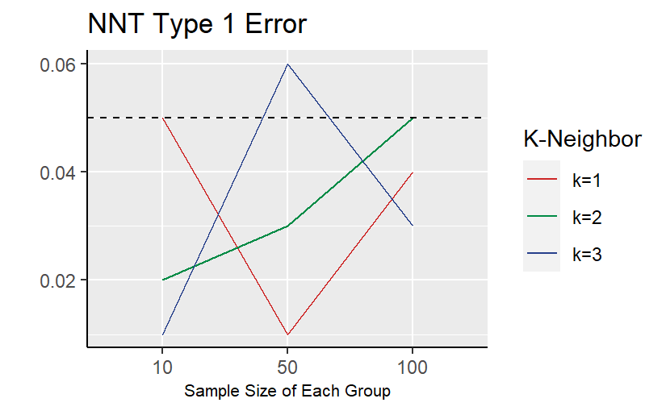

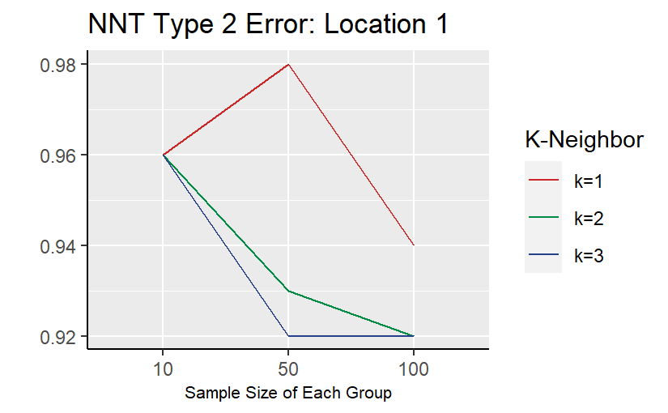

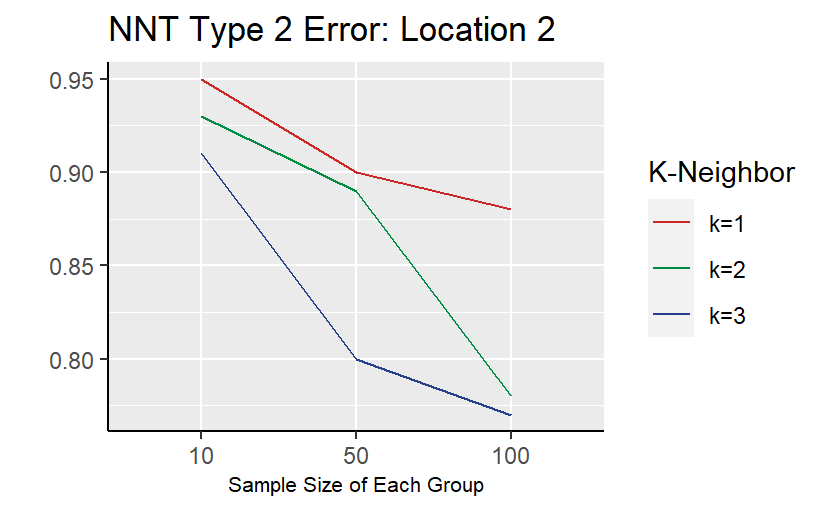

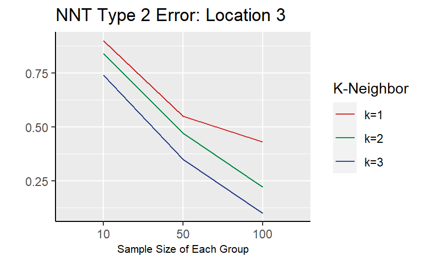

```r
# NNT Plot
NNT.TYPE.1<- nnt.results %>% select(1,3:5)
ggplot(data = NNT.TYPE.1)+
  geom_line(aes(as.factor(`n1`),`k=1`,group=1,color="firebrick3"))+
  geom_line(aes(as.factor(`n1`),`k=2`,group=1,color="springgreen4"))+
  geom_line(aes(as.factor(`n1`),`k=3`,group=1,color="royalblue4"))+
  geom_hline(yintercept=0.05, linetype="dashed", color = "black")+
  ggtitle("NNT Type 1 Error")+
  labs(x="Sample Size of Each Group",y="")+
  theme(axis.line = element_line(colour = "black"))+
  theme(axis.title.x = element_text(size=8))+
  scale_color_identity(name = "K-Neighbor",
                     breaks = c("firebrick3", "springgreen4", "royalblue4"),
                     labels = c("k=1", "k=2", "k=3"),
                     guide = "legend")

NNT.TYPE2.1<- nnt.results %>% select(1,6:8)
ggplot(data = NNT.TYPE2.1)+
  geom_line(aes(as.factor(`n1`),`k=1`,group=1,color="firebrick3"))+
  geom_line(aes(as.factor(`n1`),`k=2`,group=1,color="springgreen4"))+
  geom_line(aes(as.factor(`n1`),`k=3`,group=1,color="royalblue4"))+
  theme(axis.title.x = element_text(size=8))+
  theme(axis.line = element_line(colour = "black"))+
  labs(x="Sample Size of Each Group",y="",title = "NNT Type 2 Error: Location 1")+
  scale_color_identity(name = "K-Neighbor",
                       breaks = c("firebrick3", "springgreen4", "royalblue4"),
                       labels = c("k=1", "k=2", "k=3"),
                       guide = "legend")

NNT.TYPE2.2<- nnt.results %>% select(1,9:11)
ggplot(data = NNT.TYPE2.2)+
  geom_line(aes(as.factor(`n1`),`k=1`,group=1,color="firebrick3"))+
  geom_line(aes(as.factor(`n1`),`k=2`,group=1,color="springgreen4"))+
  geom_line(aes(as.factor(`n1`),`k=3`,group=1,color="royalblue4"))+
  theme(axis.title.x = element_text(size=8))+
  theme(axis.line = element_line(colour = "black"))+
  labs(x="Sample Size of Each Group",y="",title = "NNT Type 2 Error: Location 2")+
  scale_color_identity(name = "K-Neighbor",
                       breaks = c("firebrick3", "springgreen4", "royalblue4"),
                       labels = c("k=1", "k=2", "k=3"),
                       guide = "legend")

NNT.TYPE2.3<- nnt.results %>% select(1,12:14)
ggplot(data = NNT.TYPE2.3)+
  geom_line(aes(as.factor(`n1`),`k=1`,group=1,color="firebrick3"))+
  geom_line(aes(as.factor(`n1`),`k=2`,group=1,color="springgreen4"))+
  geom_line(aes(as.factor(`n1`),`k=3`,group=1,color="royalblue4"))+
  theme(axis.title.x = element_text(size=8))+
  theme(axis.line = element_line(colour = "black"))+
  labs(x="Sample Size of Each Group",y="",title = "NNT Type 2 Error: Location 3")+
  scale_color_identity(name = "K-Neighbor",
                       breaks = c("firebrick3", "springgreen4", "royalblue4"),
                       labels = c("k=1", "k=2", "k=3"),
                       guide = "legend")
```

### EBT

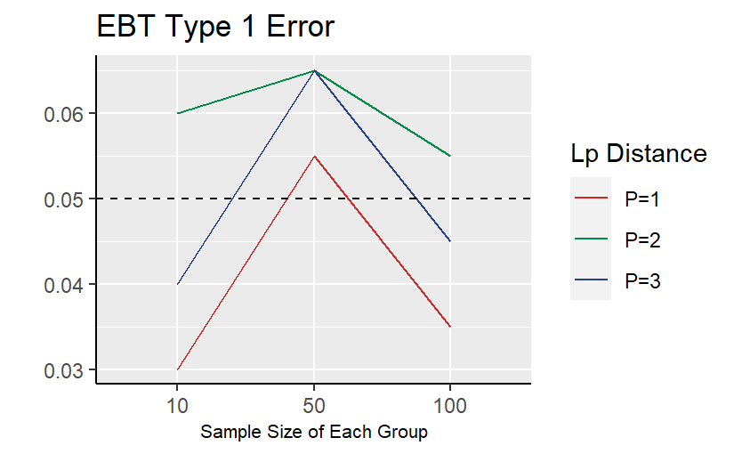

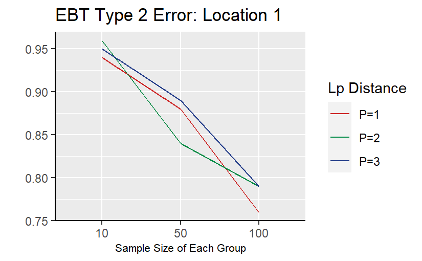

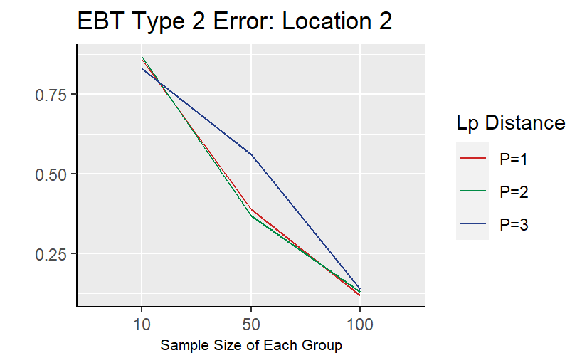

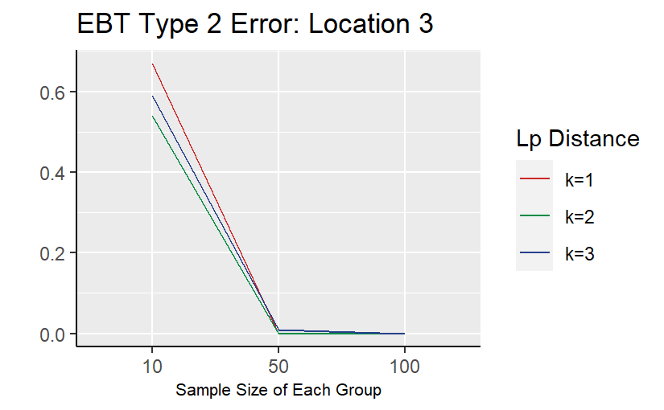

```r
EBT.TYPE.1<- EBT.Lp.results %>% select(1,3:5)
ggplot(data = EBT.TYPE.1)+
  geom_line(aes(as.factor(`n1`),`P=1`,group=1,color="firebrick3"))+
  geom_line(aes(as.factor(`n1`),`P=2`,group=1,color="springgreen4"))+
  geom_line(aes(as.factor(`n1`),`P=3`,group=1,color="royalblue4"))+
  geom_hline(yintercept=0.05, linetype="dashed", color = "black")+
  theme(axis.title.x = element_text(size=8))+
  theme(axis.line = element_line(colour = "black"))+
  labs(x="Sample Size of Each Group",y="",title = "EBT Type 1 Error")+
  scale_color_identity(name = "Lp Distance",
                       breaks = c("firebrick3", "springgreen4", "royalblue4"),
                       labels = c("P=1", "P=2", "P=3"),
                       guide = "legend")

EBT.TYPE2.1<- EBT.Lp.results %>% select(1,6:8)
ggplot(data = EBT.TYPE2.1)+
  geom_line(aes(as.factor(`n1`),`P=1`,group=1,color="firebrick3"))+
  geom_line(aes(as.factor(`n1`),`P=2`,group=1,color="springgreen4"))+
  geom_line(aes(as.factor(`n1`),`P=3`,group=1,color="royalblue4"))+
  theme(axis.title.x = element_text(size=8))+
  theme(axis.line = element_line(colour = "black"))+
  labs(x="Sample Size of Each Group",y="",title = "EBT Type 2 Error: Location 1")+
  scale_color_identity(name = "Lp Distance",
                       breaks = c("firebrick3", "springgreen4", "royalblue4"),
                       labels = c("P=1", "P=2", "P=3"),
                       guide = "legend")

EBT.TYPE2.2<- EBT.Lp.results %>% select(1,9:11)
ggplot(data = EBT.TYPE2.2)+
  geom_line(aes(as.factor(`n1`),`P=1`,group=1,color="firebrick3"))+
  geom_line(aes(as.factor(`n1`),`P=2`,group=1,color="springgreen4"))+
  geom_line(aes(as.factor(`n1`),`P=3`,group=1,color="royalblue4"))+
  theme(axis.title.x = element_text(size=8))+
  theme(axis.line = element_line(colour = "black"))+
  labs(x="Sample Size of Each Group",y="",title = "EBT Type 2 Error: Location 2")+
  scale_color_identity(name = "Lp Distance",
                       breaks = c("firebrick3", "springgreen4", "royalblue4"),
                       labels = c("P=1", "P=2", "P=3"),
                       guide = "legend")

EBT.TYPE2.3<- EBT.Lp.results %>% select(1,12:14)
ggplot(data = EBT.TYPE2.3)+
  geom_line(aes(as.factor(`n1`),`P=1`,group=1,color="firebrick3"))+
  geom_line(aes(as.factor(`n1`),`P=2`,group=1,color="springgreen4"))+
  geom_line(aes(as.factor(`n1`),`P=3`,group=1,color="royalblue4"))+
  theme(axis.title.x = element_text(size=8))+
  theme(axis.line = element_line(colour = "black"))+
  labs(x="Sample Size of Each Group",y="",title = "EBT Type 2 Error: Location 3")+
  scale_color_identity(name = "Lp Distance",
                       breaks = c("firebrick3", "springgreen4", "royalblue4"),
                       labels = c("k=1", "k=2", "k=3"),
                       guide = "legend")
```

### GST

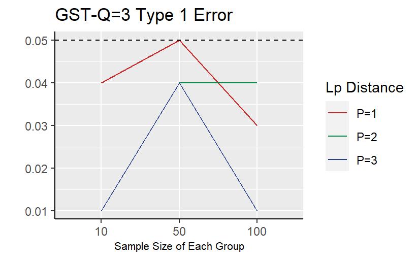

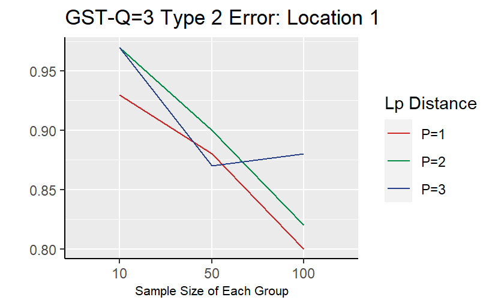

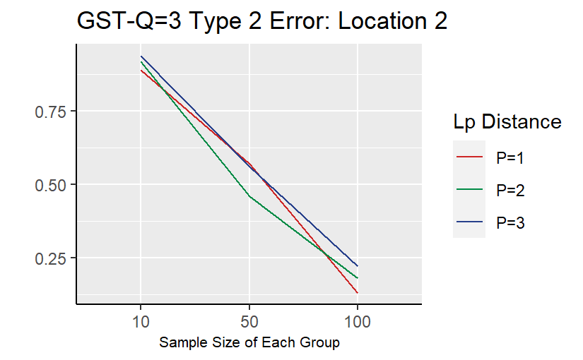

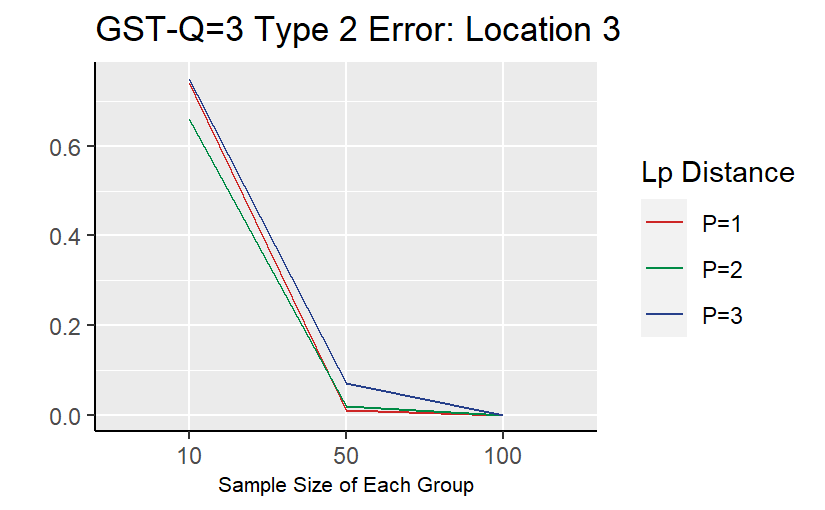

```r
GST.Q3.TYPE.1<- GST.Q.3.results %>% select(1,3:5)
ggplot(data = GST.Q3.TYPE.1)+
  geom_line(aes(as.factor(`n1`),`P=1`,group=1,color="firebrick3"))+
  geom_line(aes(as.factor(`n1`),`P=2`,group=1,color="springgreen4"))+
  geom_line(aes(as.factor(`n1`),`P=3`,group=1,color="royalblue4"))+
  geom_hline(yintercept=0.05, linetype="dashed", color = "black")+
  theme(axis.title.x = element_text(size=8))+
  theme(axis.line = element_line(colour = "black"))+
  labs(x="Sample Size of Each Group",y="",title = "GST-Q=3 Type 1 Error")+
  scale_color_identity(name = "Lp Distance",
                       breaks = c("firebrick3", "springgreen4", "royalblue4"),
                       labels = c("P=1", "P=2", "P=3"),
                       guide = "legend")

GST.Q3.TYPE2.1<- GST.Q.3.results %>% select(1,6:8)
ggplot(data = GST.Q3.TYPE2.1)+
  geom_line(aes(as.factor(`n1`),`P=1`,group=1,color="firebrick3"))+
  geom_line(aes(as.factor(`n1`),`P=2`,group=1,color="springgreen4"))+
  geom_line(aes(as.factor(`n1`),`P=3`,group=1,color="royalblue4"))+
  theme(axis.title.x = element_text(size=8))+
  theme(axis.line = element_line(colour = "black"))+
  labs(x="Sample Size of Each Group",y="",title = "GST-Q=3 Type 2 Error: Location 1")+
  scale_color_identity(name = "Lp Distance",
                       breaks = c("firebrick3", "springgreen4", "royalblue4"),
                       labels = c("P=1", "P=2", "P=3"),
                       guide = "legend")

GST.Q3.TYPE2.2<- GST.Q.3.results %>% select(1,9:11)
ggplot(data = GST.Q3.TYPE2.2)+
  geom_line(aes(as.factor(`n1`),`P=1`,group=1,color="firebrick3"))+
  geom_line(aes(as.factor(`n1`),`P=2`,group=1,color="springgreen4"))+
  geom_line(aes(as.factor(`n1`),`P=3`,group=1,color="royalblue4"))+
  theme(axis.title.x = element_text(size=8))+
  theme(axis.line = element_line(colour = "black"))+
  labs(x="Sample Size of Each Group",y="",title = "GST-Q=3 Type 2 Error: Location 2")+
  scale_color_identity(name = "Lp Distance",
                       breaks = c("firebrick3", "springgreen4", "royalblue4"),
                       labels = c("P=1", "P=2", "P=3"),
                       guide = "legend")

GST.Q3.TYPE2.3<- GST.Q.3.results %>% select(1,12:14)
ggplot(data = GST.Q3.TYPE2.3)+
  geom_line(aes(as.factor(`n1`),`P=1`,group=1,color="firebrick3"))+
  geom_line(aes(as.factor(`n1`),`P=2`,group=1,color="springgreen4"))+
  geom_line(aes(as.factor(`n1`),`P=3`,group=1,color="royalblue4"))+
  theme(axis.title.x = element_text(size=8))+
  theme(axis.line = element_line(colour = "black"))+
  labs(x="Sample Size of Each Group",y="",title = "GST-Q=3 Type 2 Error: Location 3")+
  scale_color_identity(name = "Lp Distance",
                       breaks = c("firebrick3", "springgreen4", "royalblue4"),
                       labels = c("P=1", "P=2", "P=3"),
                       guide = "legend")
```

## 2. Test Comparison

### Dimension

```r
# NNT
n.neighbor<- 3
n1<- 100
n2<- 100
location<- c(0,0.15,0.35,0.65)
dimension<-c(1,2,5,10)

## for dimension=2,5,10/ sample=100
set.seed(670486091)
times = 100
decision <- array(0,dim=c(4,times,4))

for (i in 1:4){
  n = n1
  m = n2
  d=dimension[i]
  for (j in 1:4){
    for (t in 1:times) {
      x <- matrix(rnorm(n*d), n, d)
      y <- matrix(rnorm(m*d,mean = location[j]), m, d)
      z <- rbind(x, y)
      decision[i,t,j]=NNT.perm(z, c(n,m),R=n.neighbor,alpha=0.05,B=500)
    }
  }
}
NNT.results<- matrix(0,nrow = 4, ncol = 4)
for (j in 1:4){
  for (i in 1:4){
    if (j<=1){
      NNT.results[i,j]<- mean(decision[i,,j])
    }else{
      NNT.results[i,j]<- mean(1-decision[i,,j])
    }
  }
}

NNT.RESULTS<- as_tibble(NNT.results) %>% mutate(Dimension=c(1,2,5,10))

# EBT P=2
p<- 2
n1<- 100
n2<- 100
location<- c(0,0.15,0.35,0.65)
dimension<-c(1,2,5,10)

## for dimension=2,5,10/ sample=100
set.seed(670486091)
times = 100
decision <- array(0,dim=c(4,times,4))

for (i in 1:4){
  n = n1
  m = n2
  d=dimension[i]
  for (j in 1:4){
    for (t in 1:times) {
      x <- matrix(rnorm(n*d), n, d)
      y <- matrix(rnorm(m*d,mean = location[j]), m, d)
      z <- rbind(x, y)
      dst<- L.p.distance(z,p)
      decision[i,t,j]=EBT.perm(dst, c(n,m),alpha=0.05,B=500)
    }
  }
}

EBT.results<- matrix(0,nrow = 4, ncol = 4)
for (j in 1:4){
  for (i in 1:4){
    if (j<=1){
      EBT.results[i,j]<- mean(decision[i,,j])
    }else{
      EBT.results[i,j]<- mean(1-decision[i,,j])
    }
  }
}

EBT.RESULTS<- as_tibble(EBT.results) %>% mutate(Dimension=c(1,2,5,10))

# HTT
n1<- 100
n2<- 100
location<- c(0,0.15,0.35,0.65)
dimension<-c(1,2,5,10)

## for dimension=2,5,10/ sample=100
set.seed(670486091)
times = 100
decision <- array(0,dim=c(4,times,4))

for (i in 1:4){
  n = n1
  m = n2
  d=dimension[i]
  for (j in 1:4){
    for (t in 1:times) {
      x <- matrix(rnorm(n*d), n, d)
      y <- matrix(rnorm(m*d,mean = location[j]), m, d)
      z <- rbind(x, y)
      decision[i,t,j]=HTT.perm(z, c(n,m),alpha=0.05,B=500)
    }
  }
}

HTT.results<- matrix(0,nrow = 4, ncol = 4)
for (j in 1:4){
  for (i in 1:4){
    if (j<=1){
      HTT.results[i,j]<- mean(decision[i,,j])
    }else{
      HTT.results[i,j]<- mean(1-decision[i,,j])
    }
  }
}

HTT.RESULTS<- as_tibble(HTT.results) %>% mutate(Dimension=c(1,2,5,10))

# GST test P=2 Q=3
p<- 2
Q<-3
n1<- 100
n2<- 100
location<- c(0,0.15,0.35,0.65)
dimension<-c(1,2,5,10)

## for dimension=2,5,10/ sample=100
set.seed(670486091)
times = 100
decision <- array(0,dim=c(4,times,4))

for (i in 1:4){
  n = n1
  m = n2
  d=dimension[i]
  for (j in 1:4){
    for (t in 1:times) {
      x <- matrix(rnorm(n*d), n, d)
      y <- matrix(rnorm(m*d,mean = location[j]), m, d)
      z <- rbind(x, y)
      dst<- L.p.distance(z,p)
      decision[i,t,j]=GST.perm(dst, c(n,m),Q,alpha=0.05,B=500)
    }
  }
}

GST.results<- matrix(0,nrow = 4, ncol = 4)
for (j in 1:4){
  for (i in 1:4){
    if (j<=1){
      GST.results[i,j]<- mean(decision[i,,j])
    }else{
      GST.results[i,j]<- mean(1-decision[i,,j])
    }
  }
}

GST.RESULTS<- as_tibble(GST.results) %>% mutate(Dimension=c(1,2,5,10))
```

#### Visualization

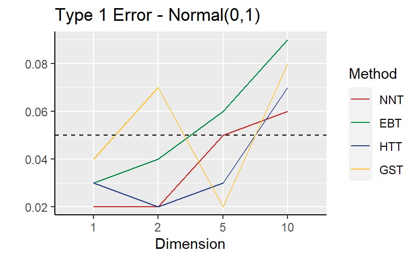

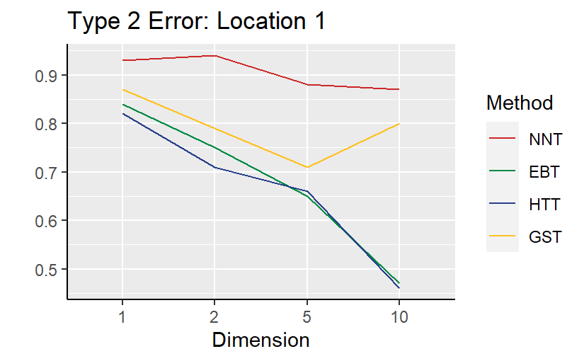

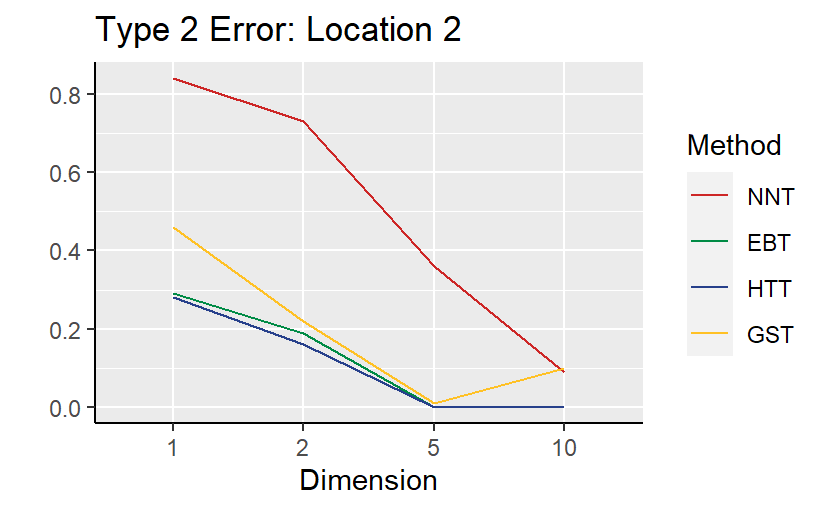

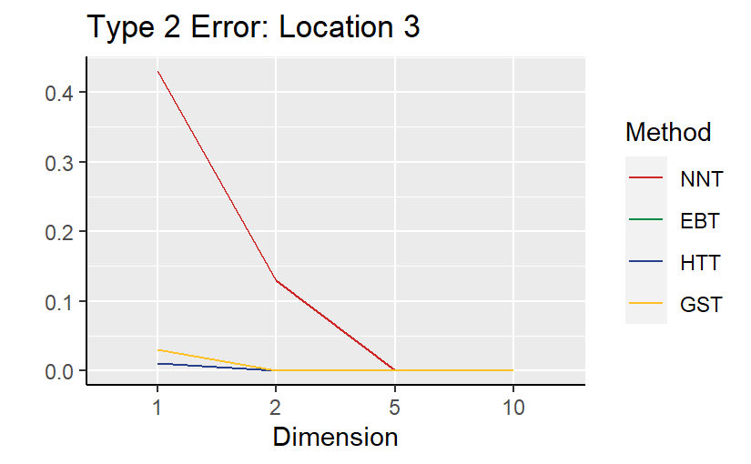

```r
# Comparison
ggplot()+
  geom_line(data=NNT.RESULTS,aes(as.factor(Dimension),V1,group=1,color="firebrick3"))+
  geom_line(data=EBT.RESULTS,aes(as.factor(Dimension),V1,group=1,color="springgreen4"))+
  geom_line(data=HTT.RESULTS,aes(as.factor(Dimension),V1,group=1,color="royalblue4"))+
  geom_line(data=GST.RESULTS,aes(as.factor(Dimension),V1,group=1,color="goldenrod1"))+
  geom_hline(yintercept=0.05, linetype="dashed", color = "black")+
  theme(axis.line = element_line(colour = "black"))+
  labs(x="Dimension",y="",title = "Type 1 Error - Normal(0,1)")+
  scale_color_identity(name = "Method",
                       breaks = c("firebrick3", "springgreen4","royalblue4","goldenrod1"),
                       labels = c("NNT", "EBT","HTT","GST"),
                       guide = "legend")
ggplot()+
  geom_line(data=NNT.RESULTS,aes(as.factor(Dimension),V2,group=1,color="firebrick3"))+
  geom_line(data=EBT.RESULTS,aes(as.factor(Dimension),V2,group=1,color="springgreen4"))+
  geom_line(data=HTT.RESULTS,aes(as.factor(Dimension),V2,group=1,color="royalblue4"))+
  geom_line(data=GST.RESULTS,aes(as.factor(Dimension),V2,group=1,color="goldenrod1"))+
  labs(x="Dimension",y="",title = "Type 2 Error: Location 1")+
  theme(axis.line = element_line(colour = "black"))+
  scale_color_identity(name = "Method",
                       breaks = c("firebrick3", "springgreen4","royalblue4","goldenrod1"),
                       labels = c("NNT", "EBT","HTT","GST"),
                       guide = "legend")

ggplot()+
  geom_line(data=NNT.RESULTS,aes(as.factor(Dimension),V3,group=1,color="firebrick3"))+
  geom_line(data=EBT.RESULTS,aes(as.factor(Dimension),V3,group=1,color="springgreen4"))+
  geom_line(data=HTT.RESULTS,aes(as.factor(Dimension),V3,group=1,color="royalblue4"))+
  geom_line(data=GST.RESULTS,aes(as.factor(Dimension),V3,group=1,color="goldenrod1"))+
  labs(x="Dimension",y="",title = "Type 2 Error: Location 2")+
  theme(axis.line = element_line(colour = "black"))+
  scale_color_identity(name = "Method",
                       breaks = c("firebrick3", "springgreen4","royalblue4","goldenrod1"),
                       labels = c("NNT", "EBT","HTT","GST"),
                       guide = "legend")
ggplot()+
  geom_line(data=NNT.RESULTS,aes(as.factor(Dimension),V4,group=1,color="firebrick3"))+
  geom_line(data=EBT.RESULTS,aes(as.factor(Dimension),V4,group=1,color="springgreen4"))+
  geom_line(data=HTT.RESULTS,aes(as.factor(Dimension),V4,group=1,color="royalblue4"))+
  geom_line(data=GST.RESULTS,aes(as.factor(Dimension),V4,group=1,color="goldenrod1"))+
  labs(x="Dimension",y="",title = "Type 2 Error: Location 3")+
  theme(axis.line = element_line(colour = "black"))+
  scale_color_identity(name = "Method",
                       breaks = c("firebrick3", "springgreen4","royalblue4","goldenrod1"),
                       labels = c("NNT", "EBT","HTT","GST"),
                       guide = "legend")
```

### Distribution/ Sensitivity

```r
## NNT-Gamma
n.neighbor<- 3
n1<- 100
n2<- 100
shape<- c(0.5,0.55,0.6,0.65)
dimension<-c(1,2,5,10)

set.seed(670486091)
times = 100
decision <- array(0,dim=c(4,times,4))

for (i in 1:4){
  n = n1
  m = n2
  d=dimension[i]
  for (j in 1:4){
    for (t in 1:times) {
      x <- matrix(rgamma(n*d,shape = 0.5,scale = 0.5), n, d)
      y <- matrix(rgamma(m*d,shape = shape[j],scale = 0.5), m, d)
      z <- rbind(x, y)
      decision[i,t,j]=NNT.perm(z, c(n,m),R=n.neighbor,alpha=0.05,B=500)
    }
  }
}
NNT.shape.results<- matrix(0,nrow = 4, ncol = 4)
for (j in 1:4){
  for (i in 1:4){
    if (j<=1){
      NNT.shape.results[i,j]<- mean(decision[i,,j])
    }else{
      NNT.shape.results[i,j]<- mean(1-decision[i,,j])
    }
  }
}

NNT.RESULTS.gamma.shape<- as_tibble(NNT.shape.results) %>% mutate(Dimension=c(1,2,5,10))

# EBT-Gamma
p<- 2
n1<- 100
n2<- 100
shape<- c(0.5,0.55,0.6,0.65)
dimension<-c(1,2,5,10)

## for dimension=1,2,5,10/ sample=100
set.seed(670486091)
times = 100
decision <- array(0,dim=c(4,times,4))

for (i in 1:4){
  n = n1
  m = n2
  d=dimension[i]
  for (j in 1:4){
    for (t in 1:times) {
      x <- matrix(rgamma(n*d,shape = 0.5,scale = 0.5), n, d)
      y <- matrix(rgamma(m*d,shape = shape[j],scale = 0.5), m, d)
      z <- rbind(x, y)
      dst<- L.p.distance(z,p)
      decision[i,t,j]=EBT.perm(dst, c(n,m),alpha=0.05,B=500)
    }
  }
}

EBT.shape.results<- matrix(0,nrow = 4, ncol = 4)
for (j in 1:4){
  for (i in 1:4){
    if (j<=1){
      EBT.shape.results[i,j]<- mean(decision[i,,j])
    }else{
      EBT.shape.results[i,j]<- mean(1-decision[i,,j])
    }
  }
}

EBT.RESULTS.gamma.shape<- as_tibble(EBT.shape.results) %>% mutate(Dimension=c(1,2,5,10))

## HTT-Gamma
n1<- 100
n2<- 100
shape<- c(0.5,0.55,0.6,0.65)
dimension<-c(1,2,5,10)

## for dimension=1,2,5,10/ sample=100
set.seed(670486091)
times = 100
decision <- array(0,dim=c(4,times,4))

for (i in 1:4){
  n = n1
  m = n2
  d=dimension[i]
  for (j in 1:4){
    for (t in 1:times) {
      x <- matrix(rgamma(n*d,shape = 0.5,scale = 0.5), n, d)
      y <- matrix(rgamma(m*d,shape = shape[j],scale = 0.5), m, d)
      z <- rbind(x, y)
      decision[i,t,j]=HTT.perm(z, c(n,m),alpha=0.05,B=500)
    }
  }
}

HTT.shape.results<- matrix(0,nrow = 4, ncol = 4)
for (j in 1:4){
  for (i in 1:4){
    if (j<=1){
      HTT.shape.results[i,j]<- mean(decision[i,,j])
    }else{
      HTT.shape.results[i,j]<- mean(1-decision[i,,j])
    }
  }
}

HTT.RESULTS.gamma.shape<- as_tibble(HTT.shape.results) %>% mutate(Dimension=c(1,2,5,10))

## GST-Gamma
p<- 2
Q<- 3
n1<- 100
n2<- 100
shape<- c(0.5,0.55,0.6,0.65)
dimension<-c(1,2,5,10)

## for dimension=1,2,5,10/ sample=100
set.seed(670486091)
times = 100
decision <- array(0,dim=c(4,times,4))

for (i in 1:4){
  n = n1
  m = n2
  d=dimension[i]
  for (j in 1:4){
    for (t in 1:times) {
      x <- matrix(rgamma(n*d,shape = 0.5,scale = 0.5), n, d)
      y <- matrix(rgamma(m*d,shape = shape[j],scale = 0.5), m, d)
      z <- rbind(x, y)
      dst<- L.p.distance(z,p)
      decision[i,t,j]=GST.perm(dst, c(n,m),Q,alpha=0.05,B=500)
    }
  }
}

GST.shape.results<- matrix(0,nrow = 4, ncol = 4)
for (j in 1:4){
  for (i in 1:4){
    if (j<=1){
      GST.shape.results[i,j]<- mean(decision[i,,j])
    }else{
      GST.shape.results[i,j]<- mean(1-decision[i,,j])
    }
  }
}

GST.RESULTS.gamma.shape<- as_tibble(GST.shape.results) %>% mutate(Dimension=c(1,2,5,10))
```

#### Visualization

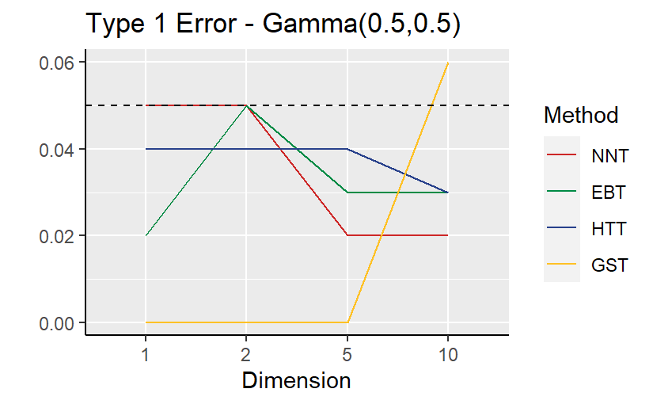

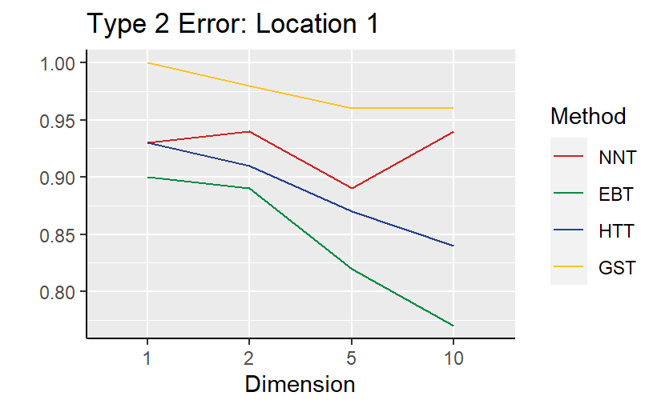

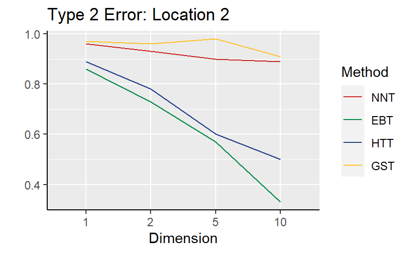

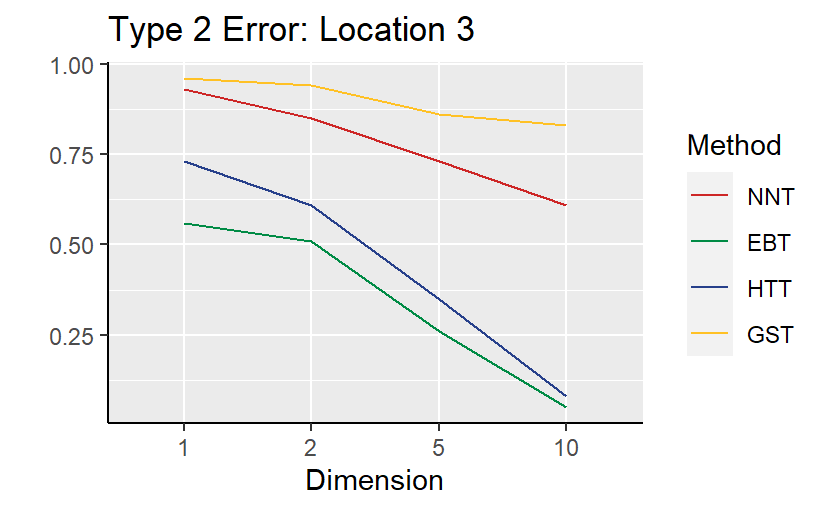

```r
# Comparison-Gamma
ggplot()+
  geom_line(data=NNT.RESULTS.gamma.shape,aes(as.factor(Dimension),V1,group=1,color="firebrick3"))+
  geom_line(data=EBT.RESULTS.gamma.shape,aes(as.factor(Dimension),V1,group=1,color="springgreen4"))+
  geom_line(data=HTT.RESULTS.gamma.shape,aes(as.factor(Dimension),V1,group=1,color="royalblue4"))+
  geom_line(data=GST.RESULTS.gamma.shape,aes(as.factor(Dimension),V1,group=1,color="goldenrod1"))+
  geom_hline(yintercept=0.05, linetype="dashed", color = "black")+
  labs(x="Dimension",y="",title = "Type 1 Error - Gamma(0.5,0.5)")+
  theme(axis.line = element_line(colour = "black"))+
  scale_color_identity(name = "Method",
                       breaks = c("firebrick3", "springgreen4","royalblue4","goldenrod1"),
                       labels = c("NNT", "EBT","HTT","GST"),
                       guide = "legend")
ggplot()+
  geom_line(data=NNT.RESULTS.gamma.shape,aes(as.factor(Dimension),V2,group=1,color="firebrick3"))+
  geom_line(data=EBT.RESULTS.gamma.shape,aes(as.factor(Dimension),V2,group=1,color="springgreen4"))+
  geom_line(data=HTT.RESULTS.gamma.shape,aes(as.factor(Dimension),V2,group=1,color="royalblue4"))+
  geom_line(data=GST.RESULTS.gamma.shape,aes(as.factor(Dimension),V2,group=1,color="goldenrod1"))+
  labs(x="Dimension",y="",title = "Type 2 Error: Location 1")+
  theme(axis.line = element_line(colour = "black"))+
  scale_color_identity(name = "Method",
                       breaks = c("firebrick3", "springgreen4","royalblue4","goldenrod1"),
                       labels = c("NNT", "EBT","HTT","GST"),
                       guide = "legend")

ggplot()+
  geom_line(data=NNT.RESULTS.gamma.shape,aes(as.factor(Dimension),V3,group=1,color="firebrick3"))+
  geom_line(data=EBT.RESULTS.gamma.shape,aes(as.factor(Dimension),V3,group=1,color="springgreen4"))+
  geom_line(data=HTT.RESULTS.gamma.shape,aes(as.factor(Dimension),V3,group=1,color="royalblue4"))+
  geom_line(data=GST.RESULTS.gamma.shape,aes(as.factor(Dimension),V3,group=1,color="goldenrod1"))+
  labs(x="Dimension",y="",title = "Type 2 Error: Location 2")+
  theme(axis.line = element_line(colour = "black"))+
  scale_color_identity(name = "Method",
                       breaks = c("firebrick3", "springgreen4","royalblue4","goldenrod1"),
                       labels = c("NNT", "EBT","HTT","GST"),
                       guide = "legend")
ggplot()+
  geom_line(data=NNT.RESULTS.gamma.shape,aes(as.factor(Dimension),V4,group=1,color="firebrick3"))+
  geom_line(data=EBT.RESULTS.gamma.shape,aes(as.factor(Dimension),V4,group=1,color="springgreen4"))+
  geom_line(data=HTT.RESULTS.gamma.shape,aes(as.factor(Dimension),V4,group=1,color="royalblue4"))+
  geom_line(data=GST.RESULTS.gamma.shape,aes(as.factor(Dimension),V4,group=1,color="goldenrod1"))+
  labs(x="Dimension",y="",title = "Type 2 Error: Location 3")+
  theme(axis.line = element_line(colour = "black"))+
  scale_color_identity(name = "Method",
                       breaks = c("firebrick3", "springgreen4","royalblue4","goldenrod1"),
                       labels = c("NNT", "EBT","HTT","GST"),
                       guide = "legend")
```

### Efficiency

```r
# Efficiency
set.seed(670486091)
n1<- 100
n2<- 100
d<-2
x <- matrix(rnorm(n1*d), n1, d)
y <- matrix(rnorm(n2*d),n2, d)
z <- rbind(x, y)
dst<- L.p.distance(z,2)

results1<- benchmark(
  columns = c("test", "replications", "elapsed", "relative"),
  replications = 10,
  Distance= dst<- L.p.distance(z,2),
  EBT= EBT.perm(dst,c(n1,n2),alpha = 0.05,B=500),
  HTT= HTT.perm(z,c(n1,n2),alpha = 0.05,B=500),
  GST= GST.perm(dst,c(n1,n2),Q=3,alpha = 0.05,B=500),
  NNT= NNT.perm(z,c(n1,n2),R=3,alpha = 0.05,B=500)
)


results1<- results1 %>% mutate(dimension=2)
results1[2,3]<- results1[2,3]+results1[1,3]
results1[3,3]<- results1[3,3]+results1[1,3]
results1<- results1[2:5,]


n1<- 100
n2<- 100
d<-5
x <- matrix(rnorm(n1*d), n1, d)
y <- matrix(rnorm(n2*d),n2, d)
z <- rbind(x, y)
dst<- L.p.distance(z,2)

results2<- benchmark(
  columns = c("test", "replications", "elapsed", "relative"),
  replications = 10,
  Distance= dst<- L.p.distance(z,2),
  EBT= EBT.perm(dst,c(n1,n2),alpha = 0.05,B=500),
  HTT= HTT.perm(z,c(n1,n2),alpha = 0.05,B=500),
  GST= GST.perm(dst,c(n1,n2),Q=3,alpha = 0.05,B=500),
  NNT= NNT.perm(z,c(n1,n2),R=3,alpha = 0.05,B=500)
)


results2<- results2 %>% mutate(dimension=5)
results2[2,3]<- results2[2,3]+results2[1,3]
results2[3,3]<- results2[3,3]+results2[1,3]
results2<- results2[2:5,]


n1<- 100
n2<- 100
d<-10
x <- matrix(rnorm(n1*d), n1, d)
y <- matrix(rnorm(n2*d),n2, d)
z <- rbind(x, y)
dst<- L.p.distance(z,2)

results3<- benchmark(
  columns = c("test", "replications", "elapsed", "relative"),
  replications = 10,
  Distance= dst<- L.p.distance(z,2),
  EBT= EBT.perm(dst,c(n1,n2),alpha = 0.05,B=500),
  HTT= HTT.perm(z,c(n1,n2),alpha = 0.05,B=500),
  GST= GST.perm(dst,c(n1,n2),Q=3,alpha = 0.05,B=500),
  NNT= NNT.perm(z,c(n1,n2),R=3,alpha = 0.05,B=500)
)

results3<- results3 %>% mutate(dimension=10)

results3[2,3]<- results3[2,3]+results3[1,3]
results3[3,3]<- results3[3,3]+results3[1,3]
results3<- results3[2:5,]


results<-rbind(results1,results2,results3)
```

#### Visualization

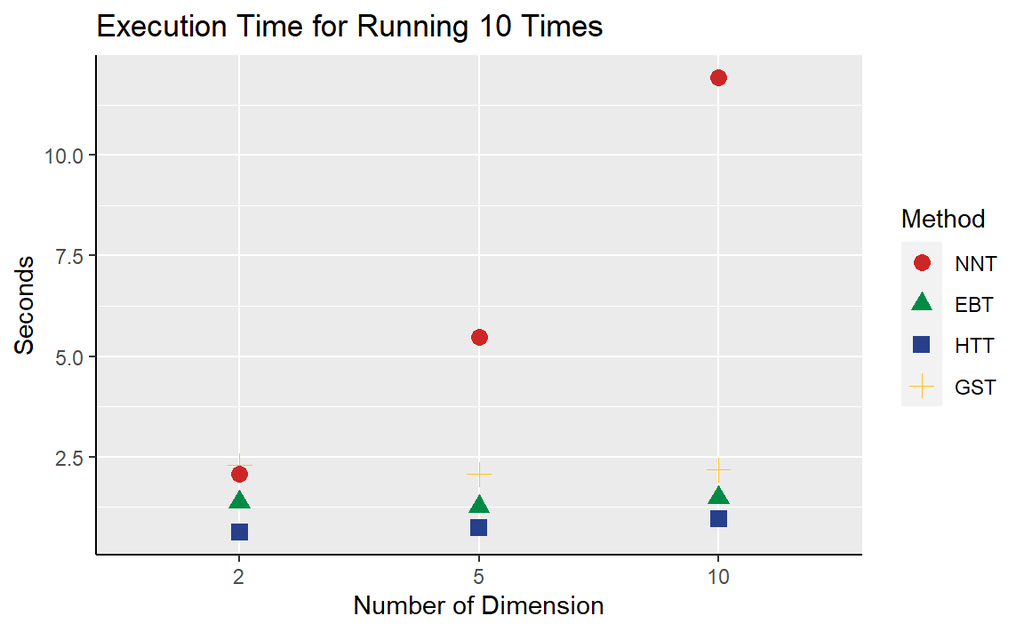

```r
ggplot(data = results)+
  theme(axis.line = element_line(colour = "black"))+
  geom_point(aes(as.factor(dimension),elapsed,shape=test,color=test),size=3)+
  labs(title = "Execution Time for Running 10 Times",y="Seconds",x="Number of Dimension")+
  labs(color = "Method",shape="Method")+
  scale_shape_discrete(limits = c("NNT", "EBT","HTT","GST"),labels = c("NNT", "EBT","HTT","GST")) +
  scale_colour_discrete(limits = c("NNT", "EBT","HTT","GST"),labels = c("NNT", "EBT","HTT","GST"))+
  scale_colour_manual(limits = c("NNT", "EBT","HTT","GST"), values=c("firebrick3","springgreen4","royalblue4","goldenrod1"))
```

## 3. Conclusion and Discussion

- Comparing the tests in various criteria, we suggest EBT test for its overall reliability across many data structures, effectiveness in controlling Type 1 error and lowering Type 2 error, and efficiency in execution. However, we note that to produce consistent results in testings, sample size for each group should at least be above 50 and dimension should be lower than 5.

# Application to Portfolio Evaluation

In this application, the goal is to evaluate two stock portfolios centered on diversified financial service banks. The overall returns and risks of 2 portfolios are evaluated through both high and low dimension parametric and non-parametric tests. The first portfolio consists of Morningstar 4-star rated diversified financial service conglomerates, and the second portfolio consists of 3-star of such conglomerates.

Data sets are from yahoo finance of the past year(251 trading days in 2021). Returns are characterized by mean and median of the average 5-day-return(50 data points each) of the portfolio, while risks are characterized by variance, skewness and kurtosis of the average 5-day-return of the portfolio. Note that the returns are first logged and differenced to stabilize.

Returns from two portfolios are paired by trading date to factor in the high linear and nonlinear relationships existed between stocks within the same industries. Hypothesis tests are executed through random shuffling of the paired returns to test whether they exhibit similar behaviors regarding returns and risks. Also, individual tests that gear toward each single factor are executed.

1. Morningstar 4-star companies:
- Citigroup Inc.
- Banco Santander, S.A.
- Westpac Banking Corporation
- Credit Suisse Group AG
1. Morningstar 3-star companies(top 4 by market capitalization):
- JPMorgan Chase & Co.
- Wells Fargo & Company
- Royal Bank of Canada
- The Toronto-Dominion Bank

## 1. Data Set

- Return is evaluated by the difference between logged adjusted close and the average return is calculated by the average return within the portfolio.
- Autocorrelations are controlled as can be observed in the ACF plots.

```r
# Morningstar 4-star
citi<- read_csv("C:\\Users\\absur\\Desktop\\Morningstar 4 star\\C.csv")
credit.suisse<-read_csv("C:\\Users\\absur\\Desktop\\Morningstar 4 star\\CS.csv")
banco<- read_csv("C:\\Users\\absur\\Desktop\\Morningstar 4 star\\SAN.csv")
wbk<- read_csv("C:\\Users\\absur\\Desktop\\Morningstar 4 star\\WBK.csv")

morning4_log<- matrix(0,nrow = 251,ncol = 4)
name<-c("citi","credit.suisse","banco","wbk")

for (i in 1:4) {
  morning4_log[,i]<-get(name[i]) %>% mutate(adj_close_log=log(`Adj Close`)) %>% pull(adj_close_log)
}
colnames(morning4_log)<-name
morning4_log<- as_tibble(morning4_log)


morning4_growth<- matrix(0,nrow = 250,ncol = 4)

for (i in 1:4) {
  morning4_growth[,i]<- diff(pull(morning4_log,name[i]))
}

colnames(morning4_growth)<-name
morning4_growth<- as_tibble(morning4_growth)
morning4_growth<- morning4_growth %>% mutate(average_return=(citi+credit.suisse+banco+wbk)/4)

## Morningstar 3-star
jpm<- read_csv("C:\\Users\\absur\\Desktop\\Morningstar 3 star\\JPM.csv")
wfc<-read_csv("C:\\Users\\absur\\Desktop\\Morningstar 3 star\\WFC.csv")
ry<-read_csv("C:\\Users\\absur\\Desktop\\Morningstar 3 star\\RY.csv")
td<-read_csv("C:\\Users\\absur\\Desktop\\Morningstar 3 star\\TD.csv")

morning3_log<- matrix(0,nrow = 251,ncol = 4)
name<-c("jpm","wfc","ry","td")

for (i in 1:4) {
  morning3_log[,i]<-get(name[i]) %>% mutate(adj_close_log=log(`Adj Close`)) %>% pull(adj_close_log)
}
colnames(morning3_log)<-name
morning3_log<- as_tibble(morning3_log)

morning3_growth<- matrix(0,nrow = 250,ncol = 4)

for (i in 1:4) {
  morning3_growth[,i]<- diff(pull(morning3_log,name[i]))
}

colnames(morning3_growth)<-name
morning3_growth<- as_tibble(morning3_growth)
morning3_growth<- morning3_growth %>% mutate(average_return=(jpm+wfc+ry+td)/4)

# adding date
morning4_growth<- as_tibble(cbind(wfc$Date[2:251],morning4_growth)) %>% rename(Date=`wfc$Date[2:251]`)
morning3_growth<- as_tibble(cbind(wfc$Date[2:251],morning3_growth)) %>% rename(Date=`wfc$Date[2:251]`)
```

### Morningstar 4-star Rating

| Date | citi | credit.suisse | banco | wbk | average_return |
| --- | --- | --- | --- | --- | --- |
| 2021-01-05 | 0.0256086878 | 0.0214896324 | 0.022545214 | 0.0106810191 | 2.008114e-02 |
| 2021-01-06 | 0.0559421296 | 0.0460022533 | 0.067718320 | 0.0275066447 | 4.929234e-02 |
| 2021-01-07 | 0.0117316843 | 0.0222310700 | 0.000000000 | 0.0077221035 | 1.042121e-02 |
| 2021-01-08 | -0.0098942491 | -0.0295091892 | 0.002971681 | 0.0038386705 | -8.148272e-03 |
| 2021-01-11 | 0.0162359351 | 0.0043732397 | 0.014727960 | -0.0006387784 | 8.674589e-03 |
| 2021-01-12 | 0.0034556407 | 0.0230059966 | 0.011627981 | 0.0171052590 | 1.379872e-02 |
| 2021-01-13 | 0.0028458350 | -0.0078487522 | -0.011627981 | 0.0025094305 | -3.530367e-03 |
| 2021-01-14 | 0.0316504768 | 0.0007160608 | 0.000000000 | 0.0229182920 | 1.382121e-02 |
| 2021-01-15 | -0.0717809318 | -0.0122435406 | -0.038753024 | 0.0012239996 | -3.038837e-02 |
| 2021-01-19 | -0.0084428106 | -0.0123953791 | 0.000000000 | 0.0103440117 | -2.623544e-03 |

[output cut: 240 more lines]

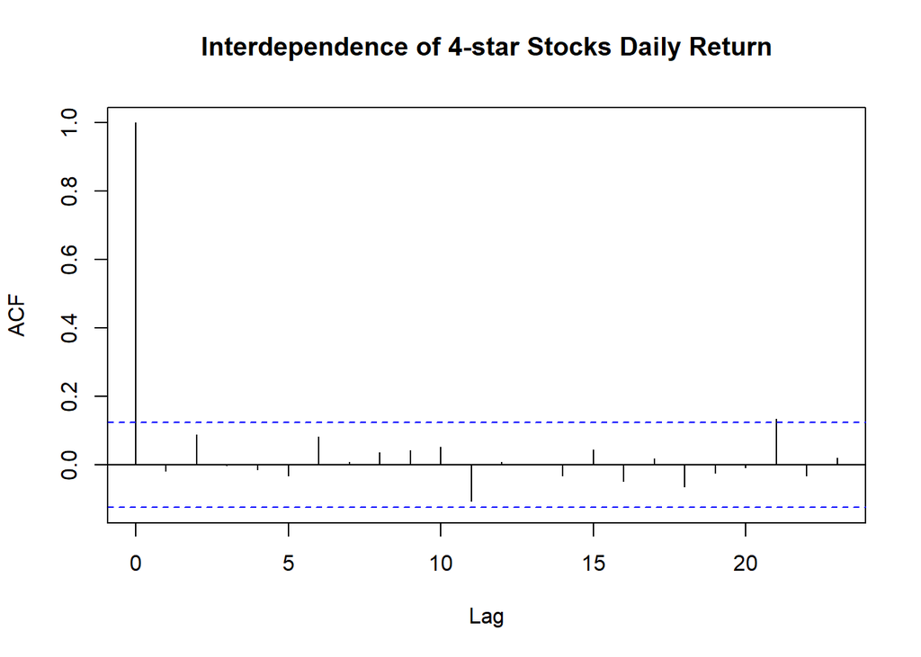

### Morningstar 3-star Rating

| Date | jpm | wfc | ry | td | average_return |
| --- | --- | --- | --- | --- | --- |
| 2021-01-05 | 5.426554e-03 | 0.0275628504 | 1.491198e-02 | 0.0135936856 | 1.537377e-02 |
| 2021-01-06 | 4.588662e-02 | 0.0683591752 | 1.493007e-02 | 0.0297137249 | 3.972240e-02 |
| 2021-01-07 | 3.231172e-02 | 0.0223845047 | 1.002671e-02 | 0.0058835146 | 1.765161e-02 |
| 2021-01-08 | 1.103372e-03 | -0.0072048499 | -2.820861e-03 | -0.0025687920 | -2.872783e-03 |
| 2021-01-11 | 1.481392e-02 | 0.0015052285 | -6.613132e-03 | -0.0027471902 | 1.739705e-03 |
| 2021-01-12 | 1.559669e-02 | 0.0208401989 | 1.072429e-02 | 0.0121338023 | 1.482375e-02 |
| 2021-01-13 | 9.266953e-04 | -0.0041333735 | 1.522728e-03 | -0.0023809418 | -1.016223e-03 |
| 2021-01-14 | 5.825422e-03 | 0.0277187993 | 1.637251e-03 | 0.0182222462 | 1.335093e-02 |
| 2021-01-15 | -1.808414e-02 | -0.0811944114 | -6.094736e-03 | -0.0092384040 | -2.865292e-02 |
| 2021-01-19 | -4.337108e-03 | 0.0182470523 | -4.595633e-03 | -0.0066029004 | 6.778526e-04 |

[output cut: 240 more lines]

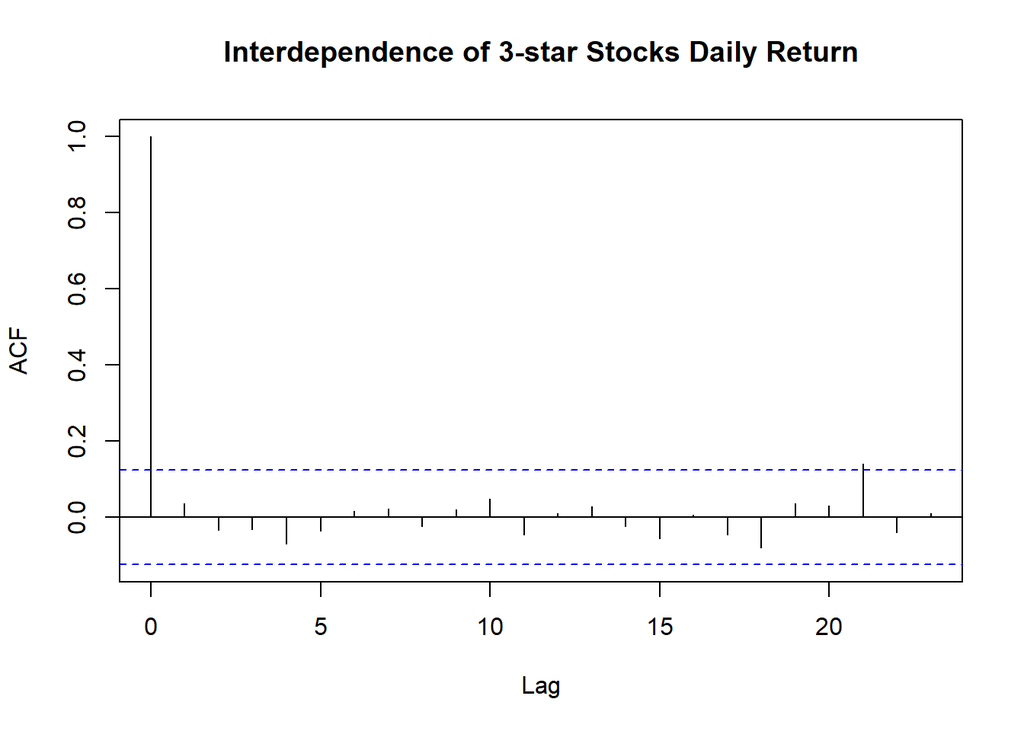

## 2. Exploratory Data Analysis

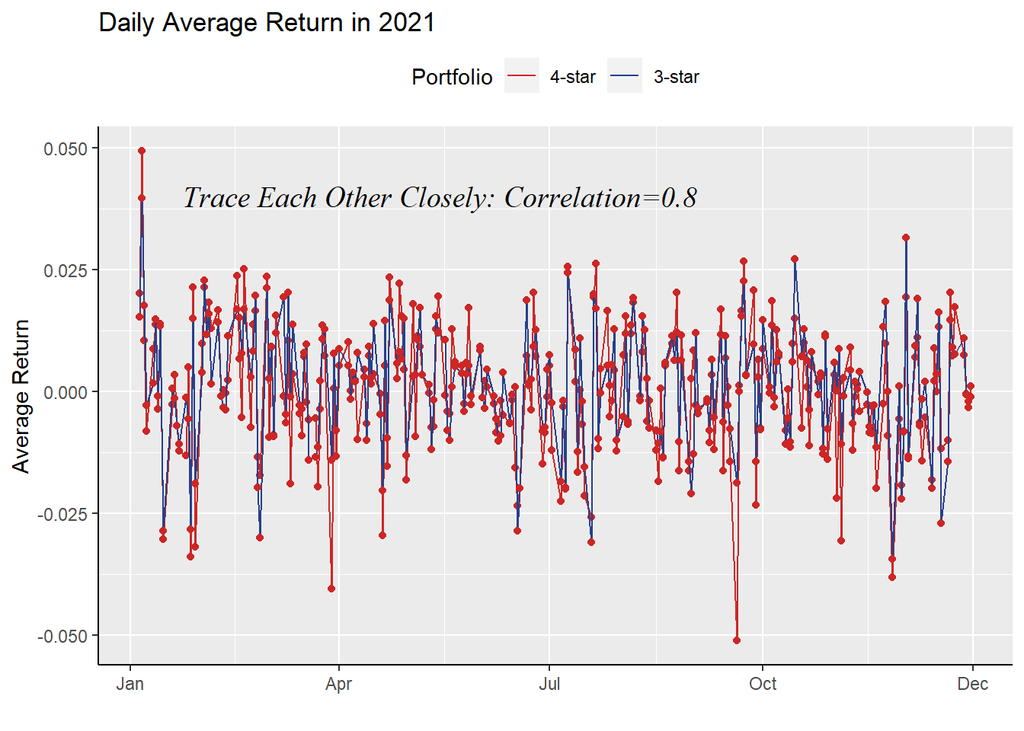

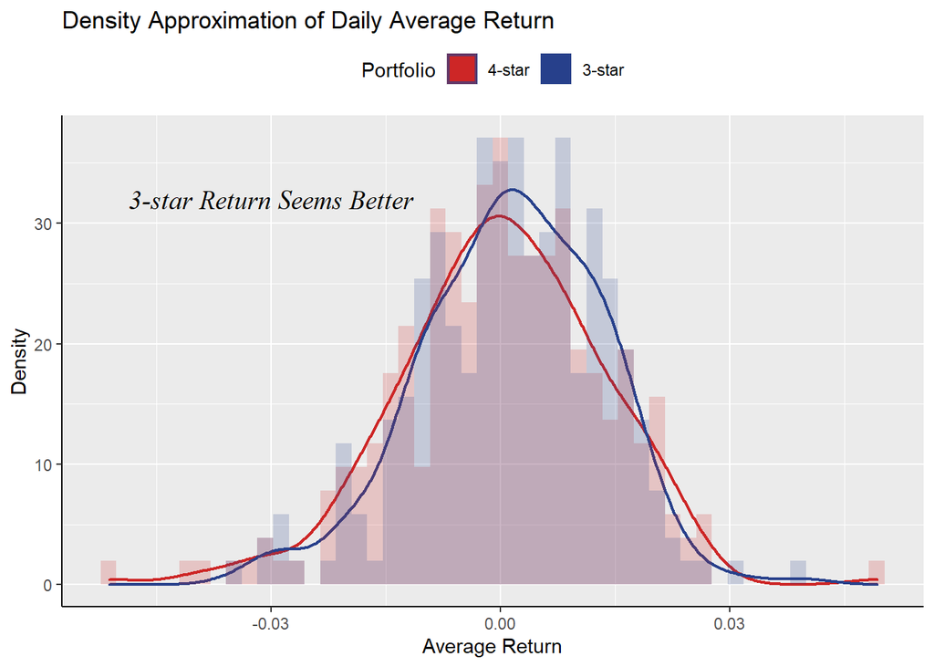

```r
datebreaks <- seq(as.Date("2021-01-01"), as.Date("2021-12-30"), by = "3 month")
datebreaks<-c(datebreaks,as.Date("2021-12-31"))
ggplot()+
  geom_line(data = morning4_growth, aes(Date,average_return,colour="firebrick3"))+
  geom_point(data = morning4_growth, aes(Date,average_return),colour="firebrick3")+
  geom_line(data = morning3_growth,aes(Date,average_return,colour="royalblue4"))+
  geom_point(data = morning3_growth,aes(Date,average_return),colour="firebrick3")+
  labs(title = "Daily Average Return in 2021",x="",y="Average Return")+
  scale_x_date(breaks = datebreaks,labels = date_format("%b"))+
  annotate("text", x = as.Date("2021-05-15"), y = 0.040, label = "Trace Each Other Closely: Correlation=0.8",
           family = "serif", fontface = "italic", colour = "black", size = 5)+
  scale_color_identity(name = "Portfolio",
                       breaks = c("firebrick3", "royalblue4"),
                       labels = c("4-star", "3-star"),
                       guide = "legend")+
  theme(axis.line = element_line(colour = "black"))+
  theme(legend.position = "top")

ggplot()+
  geom_density(data = morning4_growth,aes(average_return,y = ..density..),size=0.8,colour="firebrick3")+
  geom_density(data= morning3_growth,aes(average_return,y = ..density..),size=0.8,colour="royalblue4")+
  geom_histogram(data = morning4_growth,bins = 50,position = "identity", size = .3,alpha = 0.2,aes(x=average_return,y = ..density..,fill="firebrick3"))+
  geom_histogram(data = morning3_growth,bins = 50,position = "identity", size = .3,alpha = 0.2,aes(x=average_return,y = ..density..,fill="royalblue4"))+
  scale_fill_identity(name = "Portfolio",
                       breaks = c("firebrick3", "royalblue4"),
                       labels = c("4-star", "3-star"),
                       guide = "legend")+
  labs(title = "Density Approximation of Daily Average Return",x="Average Return",y="Density")+
  theme(legend.position = "top")+
  theme(axis.line = element_line(colour = "black"))+
  annotate("text", x = -0.03, y = 32, label = "3-star Return Seems Better",
           family = "serif", fontface = "italic", colour = "black", size = 5)
```

## 3. Hypothesis Testing

### Overall Behavior

```r
# 5-day Average & Corresponding statistics
morning3_moving<-matrix(0,nrow = 50, ncol = 5)
morning4_moving<- matrix(0,nrow = 50, ncol = 5)

index<- seq(1,255,5)

for (i in 1:50){
    morning3_moving[i,1]<- mean(morning3_growth$average_return[index[i]:(index[i+1]-1)])
    morning3_moving[i,2]<- median(morning3_growth$average_return[index[i]:(index[i+1]-1)])
    morning3_moving[i,3]<- var(morning3_growth$average_return[index[i]:(index[i+1]-1)])
    morning3_moving[i,4]<- skewness(morning3_growth$average_return[index[i]:(index[i+1]-1)],method = "sample")
    morning3_moving[i,5]<- kurtosis(morning3_growth$average_return[index[i]:(index[i+1]-1)],method = "moment")
}

for (i in 1:50){
  morning4_moving[i,1]<- mean(morning4_growth$average_return[index[i]:(index[i+1]-1)])
  morning4_moving[i,2]<- median(morning4_growth$average_return[index[i]:(index[i+1]-1)])
  morning4_moving[i,3]<- var(morning4_growth$average_return[index[i]:(index[i+1]-1)])
  morning4_moving[i,4]<- skewness(morning4_growth$average_return[index[i]:(index[i+1]-1)],method = "sample")
  morning4_moving[i,5]<- kurtosis(morning4_growth$average_return[index[i]:(index[i+1]-1)],method = "moment")
}

name<- c("mean","median","variance","skewness","kurtosis")
colnames(morning3_moving)<- name
colnames(morning4_moving)<- name

# Paired Comparison-Testing for overall difference of distribution
paired_shuffle<- function(z){
  temp<- matrix(0,nrow = 100, ncol = ncol(z))
  perm_index<- rbinom(50,1,0.5)
  for (i in 1:50) {
    if (perm_index[i]==1){
      temp[i,]<- z[i+50,]
      temp[i+50,]<-z[i,]
    }else{
      temp[i,]<- z[i,]
      temp[i+50,]<-z[i+50,]
    }
  }
  return(temp)
}

## NNT
B<- 10000
z<- rbind(morning4_moving,morning3_moving)
T0<- NNT(z,1:nrow(z),c(50,50),3)
TPerm=rep(0,B)

for (b in 1:B){
  temp<- paired_shuffle(z)
  TPerm[b]<- NNT(temp,1:nrow(temp),c(50,50),3)
}

P_overall_NNT <- mean(c(T0,TPerm) >= T0)


## HTT
B<- 10000
z<- rbind(morning4_moving,morning3_moving)
T0<- as.numeric(HTT(z,1:nrow(z),c(50,50)))
TPerm=rep(0,B)

for (b in 1:B){
  temp<- paired_shuffle(z)
  TPerm[b]<- as.numeric(HTT(temp,1:nrow(temp),c(50,50)))
}

P_overall_HTT <- mean(c(T0,TPerm) >= T0)


## EBT
B<- 10000
z<- rbind(morning4_moving,morning3_moving)
dst<- L.p.distance(z,2)
T0<- EBT(dst,1:nrow(z),c(50,50))
TPerm=rep(0,B)

for (b in 1:B){
  temp<- paired_shuffle(z)
  dst<- L.p.distance(temp,2)
  TPerm[b]<- EBT(dst,1:nrow(temp),c(50,50))
}

P_overall_EBT<- mean(c(T0,TPerm) >= T0)

## GST
B<- 10000
z<- rbind(morning4_moving,morning3_moving)
dst<- L.p.distance(z,2)
T0<- GST(dst,1:nrow(z),c(50,50),3)
TPerm=rep(0,B)

for (b in 1:B){
  temp<- paired_shuffle(z)
  dst<- L.p.distance(temp,2)
  TPerm[b]<- GST(dst,1:nrow(temp),c(50,50),3)
}

P_overall_GST<- mean(c(T0,TPerm) >= T0)

P_value<- round(c(P_overall_NNT,P_overall_EBT,P_overall_HTT,P_overall_GST),2)
Decision<- c("Fail to Reject","Fail to Reject","Reject","Fail to Reject")
results<-as.data.frame(rbind(P_value,Decision))
colnames(results)<-c("NNT","EBT","HTT","GST")
rownames(results)<-c("P-value","Decision")
results
```

|  | NNT | EBT | HTT | GST |
| --- | --- | --- | --- | --- |
| P-value | 0.15 | 0.2 | 0.01 | 0.96 |
| Decision | Fail to Reject | Fail to Reject | Reject | Fail to Reject |

### Return

```r
# Testing for return
z<- rbind(morning4_moving,morning3_moving)
z_return<-  z[,1:2]
dst1<-L.p.distance(z_return,2)

## NNT
B<- 10000
z<- rbind(morning4_moving,morning3_moving)
z_return<-  z[,1:2]
T0<- NNT(z_return,1:nrow(z),c(50,50),3)
TPerm=rep(0,B)

for (b in 1:B){
  temp<- paired_shuffle(z_return)
  TPerm[b]<- NNT(temp,1:nrow(temp),c(50,50),3)
}

P_return_NNT <- mean(c(T0,TPerm) >= T0)



## HTT
B<- 10000
z<- rbind(morning4_moving,morning3_moving)
z_return<-  z[,1:2]
T0<- as.numeric(HTT(z_return,1:nrow(z),c(50,50)))
TPerm=rep(0,B)

for (b in 1:B){
  temp<- paired_shuffle(z_return)
  TPerm[b]<- as.numeric(HTT(temp,1:nrow(temp),c(50,50)))
}

P_return_HTT<- mean(c(T0,TPerm) >= T0)


## EBT
B<- 10000
z<- rbind(morning4_moving,morning3_moving)
z_return<-  z[,1:2]
dst1<- L.p.distance(z_return,2)
T0<- EBT(dst1,1:nrow(z),c(50,50))
TPerm=rep(0,B)

for (b in 1:B){
  temp<- paired_shuffle(z_return)
  dst<- L.p.distance(temp,2)
  TPerm[b]<- EBT(dst,1:nrow(temp),c(50,50))
}

P_return_EBT<- mean(c(T0,TPerm) >= T0)


## GST
B<- 10000
z<- rbind(morning4_moving,morning3_moving)
z_return<-  z[,1:2]
dst1<- L.p.distance(z_return,2)
T0<- GST(dst1,1:nrow(z),c(50,50),3)
TPerm=rep(0,B)

for (b in 1:B){
  temp<- paired_shuffle(z_return)
  dst<- L.p.distance(temp,2)
  TPerm[b]<- GST(dst,1:nrow(temp),c(50,50),3)
}

P_return_GST<- mean(c(T0,TPerm) >= T0)

P_value<- round(c(P_return_NNT,P_return_EBT,P_return_HTT,P_return_GST),2)
Decision<- c("Fail to Reject","Reject","Fail to Reject","Fail to Reject")
results<-as.data.frame(rbind(P_value,Decision))
colnames(results)<-c("NNT","EBT","HTT","GST")
rownames(results)<-c("P-value","Decision")
results
```

|  | NNT | EBT | HTT | GST |
| --- | --- | --- | --- | --- |
| P-value | 0.14 | 0.01 | 0.13 | 1 |
| Decision | Fail to Reject | Reject | Fail to Reject | Fail to Reject |

### Risk

```r
# Testing for risks
z<- rbind(morning4_moving,morning3_moving)
z_risk<-  z[,3:5]
dst2<-L.p.distance(z_risk,2)

## NNT
B<- 10000
z<- rbind(morning4_moving,morning3_moving)
z_risk<-  z[,3:5]
T0<- NNT(z_risk,1:nrow(z),c(50,50),3)
TPerm=rep(0,B)

for (b in 1:B){
  temp<- paired_shuffle(z_risk)
  TPerm[b]<- NNT(temp,1:nrow(temp),c(50,50),3)
}

P_risk_NNT <- mean(c(T0,TPerm) >= T0)


## HTT
B<- 10000
z<- rbind(morning4_moving,morning3_moving)
z_risk<-  z[,3:5]
T0<- as.numeric(HTT(z_risk,1:nrow(z),c(50,50)))
TPerm=rep(0,B)

for (b in 1:B){
  temp<- paired_shuffle(z_risk)
  TPerm[b]<- as.numeric(HTT(temp,1:nrow(temp),c(50,50)))
}

P_risk_HTT<- mean(c(T0,TPerm) >= T0)


## EBT
B<- 10000
z<- rbind(morning4_moving,morning3_moving)
z_risk<-  z[,3:5]
dst2<- L.p.distance(z_risk,2)
T0<- EBT(dst2,1:nrow(z),c(50,50))
TPerm=rep(0,B)

for (b in 1:B){
  temp<- paired_shuffle(z_risk)
  dst<- L.p.distance(temp,2)
  TPerm[b]<- EBT(dst,1:nrow(temp),c(50,50))
}

P_risk_EBT<- mean(c(T0,TPerm) >= T0)


## GST
B<- 10000
z<- rbind(morning4_moving,morning3_moving)
z_risk<-  z[,3:5]
dst2<- L.p.distance(z_risk,2)
T0<- GST(dst2,1:nrow(z),c(50,50),3)
TPerm=rep(0,B)

for (b in 1:B){
  temp<- paired_shuffle(z_risk)
  dst<- L.p.distance(temp,2)
  TPerm[b]<- GST(dst,1:nrow(temp),c(50,50),3)
}

P_risk_GST<- mean(c(T0,TPerm) >= T0)

P_value<- round(c(P_risk_NNT,P_risk_EBT,P_risk_HTT,P_risk_GST),2)
Decision<- c("Fail to Reject","Fail to Reject","Reject","Fail to Reject")
results<-as.data.frame(rbind(P_value,Decision))
colnames(results)<-c("NNT","EBT","HTT","GST")
rownames(results)<-c("P-value","Decision")
results
```

|  | NNT | EBT | HTT | GST |
| --- | --- | --- | --- | --- |
| P-value | 0.18 | 0.2 | 0.03 | 0.96 |
| Decision | Fail to Reject | Fail to Reject | Reject | Fail to Reject |

### Individual Factor

```r
## Mean
z<- rbind(morning4_moving,morning3_moving)
z_mean<-z[,1,drop=F]
B<- 10000
T0<- median(z_mean[1:50]-z_mean[51:100])
TPerm=rep(0,B)

for (b in 1:B){
  temp<- paired_shuffle(z_mean)
  TPerm[b]<- median(temp[1:50]-temp[51:100])
}

Diff1<-T0
P_single_mean <- mean(c(abs(T0), abs(TPerm)) >= abs(T0))

## Median
z<- rbind(morning4_moving,morning3_moving)
z_median<-z[,2,drop=F]
B<- 10000
T0<- mean(z_median[1:50,]-z_median[51:100,])
TPerm=rep(0,B)

for (b in 1:B){
  temp<- paired_shuffle(z_median)
  TPerm[b]<- mean(temp[1:50]-temp[51:100])
}

Diff2<-T0
P_single_median <- mean(c(abs(T0), abs(TPerm)) >= abs(T0))

## variance
z<- rbind(morning4_moving,morning3_moving)
z_variance<-z[,3,drop=F]
B<- 10000
T0<- median(z_variance[1:50]-z_variance[51:100])
TPerm=rep(0,B)

for (b in 1:B){
  temp<- paired_shuffle(z_variance)
  TPerm[b]<- median(temp[1:50]-temp[51:100])
}

Diff3<-T0
P_single_variance <- mean(c(abs(T0), abs(TPerm)) >= abs(T0))

## skewness
z<- rbind(morning4_moving,morning3_moving)
z_skewness<-z[,4,drop=F]
B<- 10000
T0<- median(z_skewness[1:50]-z_skewness[51:100]) #tail tend to be more on the right
TPerm=rep(0,B)

for (b in 1:B){
  temp<- paired_shuffle(z_skewness)
  TPerm[b]<- median(temp[1:50]-temp[51:100])
}

Diff4<-T0
P_single_skewness <- mean(c(abs(T0), abs(TPerm)) >= abs(T0))

## kurtosis
z<- rbind(morning4_moving,morning3_moving)
z_kurtosis<-z[,5,drop=F]
B<- 10000
T0<- median(z_kurtosis[1:50]-z_kurtosis[51:100])
TPerm=rep(0,B)

for (b in 1:B){
  temp<- paired_shuffle(z_kurtosis)
  TPerm[b]<- median(temp[1:50]-temp[51:100])
}

Diff5<-T0
P_single_kurtosis<- mean(c(abs(T0), abs(TPerm)) >= abs(T0))

Difference<- round(c(Diff1,Diff2,Diff3,Diff4,Diff5),3)
P_value<- round(c(P_single_mean,P_single_median,P_single_variance,P_single_skewness,P_single_kurtosis),3)
Decision<-c("Reject","Fail to Reject","Fail to Reject","Fail to Reject","Fail to Reject")
results<- as.data.frame(rbind(Difference,P_value,Decision))
rownames(results)<-c("Difference","P-value","Decision")
colnames(results)<-c("Mean","Median","Variance","Skewness","Kurtosis")
results
```

|  | Mean | Median | Variance | Skewness | Kurtosis |
| --- | --- | --- | --- | --- | --- |
| Difference | -0.002 | -0.001 | 0 | 0.327 | 0.133 |
| P-value | 0.003 | 0.397 | 0.135 | 0.374 | 0.091 |
| Decision | Reject | Fail to Reject | Fail to Reject | Fail to Reject | Fail to Reject |

## 4. Conclusion and Discussion

- For overall behavior of the two portfolios, the results suggest that there is no significant different. However, HTT suggests there is difference. HTT statistics are sensitive to mean and variance, and thus, it is important we evaluate these parameters individually as well.
- Regarding returns, mean and median of 5-day average return are considered as a whole. Mean is much more sensitive to extreme value, while median is more robust. The test results are mixed but EBT, which are the most reliable tests among the four, concludes there is an overall difference. Thus, it should be noted that the behavior of return may be different individually.
- Regarding risks, variance, skewness, and kurtosis are considered as a whole. The results suggest there is no overall difference. Note again HTT suggests there is difference, but the P-value is close to boundary, which indicates the decision may not be consistent.
- To be prudent, individual tests targeting single factors are carried out. Median of the differences between each factor from the two portfolios is used as the statistics to measure differences. In this way, decisions would be more robust to extreme value. The results suggest that means are indeed different, but medians are not. This result provides an explanation of why the decisions are mixed regarding returns as a whole previously. In addition, each difference of risk factors are not significant, and thus, it would be safe to conclude that the overall risk factors are not different.
- In conclusion, the mean of 5-day average return of 3-star portfolio is higher than that of 4-star portfolio by 0.2%, while the difference of risks are not significant. If the overall behavior/ distribution regarding return and risks is to be compared, the results suggest there is no significant different.

# Application to Treatment Effects

In this application, we consider 4 variables (4 dimension). From the below density approximation plots, we see that means, the white dot, are quite close in value and also the general appearance of the density curves are similar. To understand the quantitative differences, we must perform statistical tests. With alpha level set at 0.05, we conclude the following:

## 1. Data Set

```r
pros.data = read.table("https://web.stanford.edu/~hastie/ElemStatLearn/datasets/prostate.data")
X=pros.data[pros.data$age>65, c('lpsa','lweight','lcp','lbph')]
Y=pros.data[pros.data$age<=65, c('lpsa','lweight','lcp','lbph')]
z<-rbind(X,Y)
pros.data
```

|  | lcavol | lweight | age | lbph | svi | lcp | gleason | pgg45 | lpsa | train |
| --- | --- | --- | --- | --- | --- | --- | --- | --- | --- | --- |
| 1 | -0.579818495 | 2.769459 | 50 | -1.38629436 | 0 | -1.38629436 | 6 | 0 | -0.4307829 | TRUE |
| 2 | -0.994252273 | 3.319626 | 58 | -1.38629436 | 0 | -1.38629436 | 6 | 0 | -0.1625189 | TRUE |
| 3 | -0.510825624 | 2.691243 | 74 | -1.38629436 | 0 | -1.38629436 | 7 | 20 | -0.1625189 | TRUE |
| 4 | -1.203972804 | 3.282789 | 58 | -1.38629436 | 0 | -1.38629436 | 6 | 0 | -0.1625189 | TRUE |
| 5 | 0.751416089 | 3.432373 | 62 | -1.38629436 | 0 | -1.38629436 | 6 | 0 | 0.3715636 | TRUE |
| 6 | -1.049822124 | 3.228826 | 50 | -1.38629436 | 0 | -1.38629436 | 6 | 0 | 0.7654678 | TRUE |
| 7 | 0.737164066 | 3.473518 | 64 | 0.61518564 | 0 | -1.38629436 | 6 | 0 | 0.7654678 | FALSE |
| 8 | 0.693147181 | 3.539509 | 58 | 1.53686722 | 0 | -1.38629436 | 6 | 0 | 0.8544153 | TRUE |
| 9 | -0.776528789 | 3.539509 | 47 | -1.38629436 | 0 | -1.38629436 | 6 | 0 | 1.0473190 | FALSE |
| 10 | 0.223143551 | 3.244544 | 63 | -1.38629436 | 0 | -1.38629436 | 6 | 0 | 1.0473190 | FALSE |

[output cut: 87 more lines]

## 2. Exploratory Data Analysis

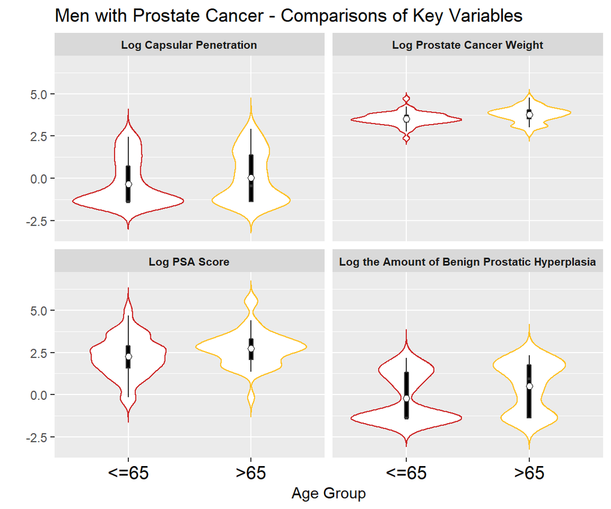

```r
## Violin Plot
pros.data = read.table("https://web.stanford.edu/~hastie/ElemStatLearn/datasets/prostate.data")
pros.data$group<-ifelse(pros.data$age>65,">65","<=65")

pros.data.plotting<- pros.data %>% select('lpsa','lweight','lcp','lbph','group')
pros.data.plotting<- pros.data.plotting %>% rename("Log PSA Score"=lpsa,
                                                   "Log Prostate Cancer Weight"=lweight,
                                                   "Log Capsular Penetration"=lcp,
                                                   "Log the Amount of Benign Prostatic Hyperplasia"=lbph)

pros.data.long<- pivot_longer(pros.data.plotting,c('Log PSA Score','Log Prostate Cancer Weight','Log Capsular Penetration','Log the Amount of Benign Prostatic Hyperplasia'),
                                  names_to = "variable",values_to = "value")


ggplot(data = pros.data.long,aes(group,value)) +
  geom_violin(trim = FALSE,adjust = .8,aes(colour=group))+
  geom_boxplot(width = .03, fill = "black", outlier.colour = NA) +
  stat_summary(fun = mean, geom = "point", fill = "white", shape = 21, size = 2)+
  facet_wrap(~variable)+
  labs(x="Age Group", y="")+
  ggtitle("Men with Prostate Cancer - Comparisons of Key Variables")+
  theme(strip.text = element_text(face = "bold",size = 8))+
  theme(axis.text.x = element_text(colour = "black", size = rel(1.5)))+
  scale_colour_manual(limits = c("<=65", ">65"), values=c("firebrick3","goldenrod1"))+
  theme(legend.position = "none")
```

## 3. Hypothesis Testing

```r
NNT.perm(z,c(43,54),R=3,alpha=0.05,B=1000)
```

```
## [1] FALSE
```

```r
dst<- L.p.distance(z,2)
EBT.perm(dst,c(43,54),alpha = 0.05,B=1000)
```

```
## [1] TRUE
```

```r
HTT.perm(as.matrix(z),c(43,54),alpha = 0.05,B=1000)
```

```
## [1] TRUE
```

```r
GST.perm(dst,c(43,54),Q=3,alpha = 0.05,B=1000)
```

```
## [1] FALSE
```

```r
test<- data.frame(NNT="Fail to Reject",EBT="Reject",HTT="Reject",GST="Fail to Reject")
test
```

| NNT | EBT | HTT | GST |
| --- | --- | --- | --- |
| Fail to Reject | Reject | Reject | Fail to Reject |

## 4. Conclusion and Discussion

- EBT and HTT conclude that there is indeed an overall difference, while GST and NNT conclude the contrary.
- In this data set, we have around 50 samples for each group and we test only for 4 dimension. We know that HTT and EBT performs better in these settings.
- We conclude that there is indeed an overall difference between people younger and older than 65, since EBT and HTT are more powerful and reliable tests in this case.